# CNN - Vegetable Dataset

Name: Ryan Yeo  
Admin Number: P2214452  
Class: DAAA/FT/2B/01  
Module Code: ST1504 Deep Learning

Resources:

- Data Augmentation
  - https://archive.is/nIlry
  - https://machinelearningmastery.com/how-to-configure-image-data-augmentation-when-training-deep-learning-neural-networks/
- Learning Rate Scheduler
  - https://keras.io/api/callbacks/learning_rate_scheduler/
  - https://machinelearningmastery.com/using-learning-rate-schedules-deep-learning-models-python-keras/
  - https://neptune.ai/blog/how-to-choose-a-learning-rate-scheduler
  - https://towardsdatascience.com/learning-rate-schedules-and-adaptive-learning-rate-methods-for-deep-learning-2c8f433990d1
- Batch Normalization
  - https://www.reddit.com/r/MachineLearning/comments/67gonq/d_batch_normalization_before_or_after_relu/

**Note**:

The observations written in this notebook are made based on the outputs when I ran it (which can be found in the HTML and PDF files). Rerunning the notebook can vary the result but ultimately, the results from the observations should remain largely relevant

```python
import os
import numpy as np
import pandas as pd
import random

import matplotlib.pyplot as plt
import seaborn as sns

from sklearn.metrics import classification_report
import tensorflow as tf
import keras
from keras.layers import Conv2D, MaxPooling2D, Flatten, Dense, Dropout, BatchNormalization, Rescaling, AveragePooling2D
from tensorflow.keras import regularizers
from keras.models import Sequential
from keras.optimizers import Adam
```

Check for existence of GPU

```python
gpus = tf.config.experimental.list_physical_devices('GPU')
for gpu in gpus:
    tf.config.experimental.set_memory_growth(gpu, True)
len(gpus)
```

```
1
```

Clear the backend

```python
tf.keras.backend.clear_session()
```

```python
seed = 42
np.random.seed(seed)
keras.utils.set_random_seed(seed)
tf.random.set_seed(seed)
```

**Batchsize**

The batch size defines the number of samples that will be propagated through the network.

For a batchsize of 64, the model akes the first 64 samples from the training dataset and trains the network. It then takes the next 64 samples and trains the network again. This procedure repeats until all the samples have been used.

Typically, large batch sizes tend to lead to faster training times but may result in lower accuracy and overfitting while smaller batchs sizes can provide better accuracy but can be computationally expensive and time-consuming

[figure not shown]

```python
batch_size = 64
```

Let's start off with writing some utilities functions which we will use later on

**Utility Functions**

```python
def load_images(dir, img_height, img_width, colormode, batch_size=None, seed=seed):
    """
        This function loads images from directory

        Parameters:
            dir (str): Directory path
            img_height (int): Image height
            img_width (int): Image width
            colormode (str): Color mode
            batch_size (int): Batch size
            seed (int): Seed value
    """
    data = tf.keras.preprocessing.image_dataset_from_directory(
        dir,
        seed=seed,
        image_size=(img_height, img_width),
        batch_size=batch_size,
        color_mode=colormode
    )

    return data
```

```python
def try_unbatch(data):
    """
        This function tries to unbatch the data.
        If the data is already unbatched, it returns the data as it is.
        If the data is batched, it unbatch the data and returns it.
    """
    try:
        data = data.unbatch()
    except:
        data = data

    return data
```

```python
# Plot the training and validation accuracy and loss at each epoch
def plot_history(model, history, epochs):
    """
        This function plots the training and validation accuracy and loss at each epoch

        Parameters:
            model (keras.models): Keras model
            history (keras.callbacks.History): History object
            epochs (int): Number of epochs
            test_data (tf.data.Dataset): Test data
    """
    fig, ax = plt.subplots(1, 2, figsize=(20, 8))

    ax = ax.ravel()

    for i, metric in enumerate(['accuracy', 'loss']):
        ax[i].plot(range(epochs), history.history[metric])
        ax[i].plot(range(epochs), history.history['val_' + metric])
        ax[i].set_title(f"Model {metric}")
        ax[i].set_xlabel("Epochs")
        ax[i].set_ylabel(metric)
        ax[i].legend(['train', 'val'])

    # Set y ticks for plot
    ax[0].set_yticks(list(map(lambda x: round(x, ndigits=2), np.linspace(0, 1, 11).tolist())))
    ax[1].set_yticks(list(map(lambda x: round(x, ndigits=2), np.linspace(0, 3, 13).tolist())))
```

```python
def save_model_performance(df, model, hist, dataName):
    """
        This function saves the model performance in a dataframe

        Parameters:
            df (pandas.core.frame.DataFrame): Pandas dataframe
            model (keras.models): Keras model
            hist (keras.callbacks.History): History object
            dataName (str): Data name
    """
    model_hist = {}
    model_hist["Data"] = dataName

    for keys in ['loss', 'accuracy', 'val_loss', 'val_accuracy']:
        model_hist[f"Mean {keys}"] = np.array(hist.history[keys]).mean()

    # Convert to pandas dataframe with index as model name
    return pd.concat([df, pd.DataFrame(model_hist, index=[model.name])])
```

### **Loading Data**

Loading data for 31 by 31 pixels

```python
root_dir = os.path.join(os.getcwd(), 'DatasetA')
train_dir = os.path.join(root_dir, 'train')
val_dir = os.path.join(root_dir, 'validation')
test_dir = os.path.join(root_dir, 'test')

img_height = 31
img_width = 31
colormode = 'grayscale'

# Load train data
train_31 = load_images(train_dir, img_height, img_width, colormode, seed=seed)

# Load validation data
val_31 = load_images(val_dir, img_height, img_width, colormode, seed=seed)

# Load test data
test_31 = load_images(test_dir, img_height, img_width, colormode, seed=seed)

classes = train_31.class_names
num_classes = len(classes)

print('\n')
print("Number of classes: ", num_classes)
print("Classes: ", classes)
```

```
Found 9028 files belonging to 15 classes.
Found 3000 files belonging to 15 classes.
Found 3000 files belonging to 15 classes.


Number of classes:  15
Classes:  ['Bean', 'Bitter_Gourd', 'Bottle_Gourd', 'Brinjal', 'Broccoli', 'Cabbage', 'Capsicum', 'Carrot', 'Cauliflower', 'Cucumber', 'Papaya', 'Potato', 'Pumpkin', 'Radish', 'Tomato']
```

Before we begin training the model, let's take a look at how the images look like

```python
def plot_images(data, n_rows=3,n_cols=5, cmap=None):
    plt.figure(figsize=(n_cols*2, n_rows*1.8))

    seen_labels = set()
    num_plots = 0

    try_unbatch(data)

    # data.take takes a random batch of images with size specified
    for images, labels in data:
        if classes[labels] not in seen_labels:
            plt.subplot(n_rows, n_cols, num_plots+1)
            # By default, imshow() uses a cmap of viridis
            plt.imshow(images.numpy().astype('uint16'), cmap=cmap)
            plt.title(classes[labels])
            plt.axis('off')

            seen_labels.add(classes[labels])
            num_plots+=1
```

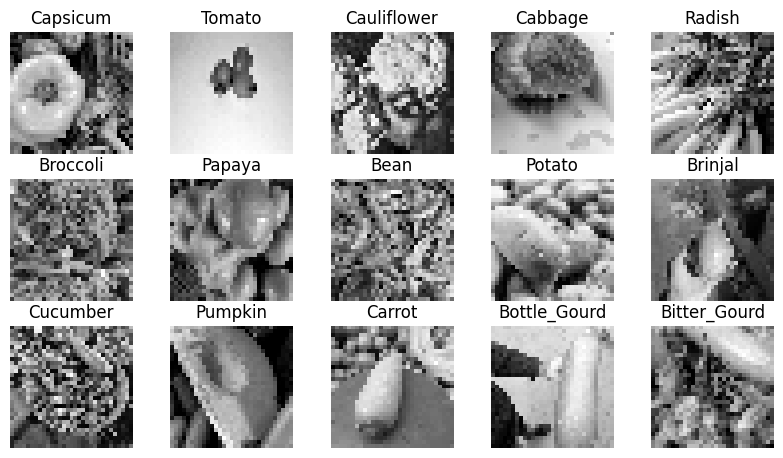

```python
plot_images(data=train_31, cmap='gray')
```

Loading data 128x128

```python
img_height = 128
img_width = 128
colormode = 'grayscale'

# Load train data
train_128 = load_images(train_dir, img_height, img_width, colormode, seed=seed)

# Load validation data
val_128 = load_images(val_dir, img_height, img_width, colormode, seed=seed)

# Load test data
test_128 = load_images(test_dir, img_height, img_width, colormode, seed=seed)
```

```
Found 9028 files belonging to 15 classes.
Found 3000 files belonging to 15 classes.
Found 3000 files belonging to 15 classes.
```

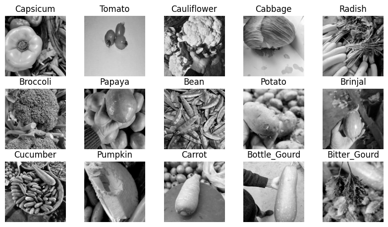

```python
plot_images(data=train_128, cmap='gray')
```

We can see that the images with 128 by 128 pixels has much more clarity and are much more discernable

### **Exploratory Data Analysis**

#### Class Imbalance

First, let us check if there is any class imbalance based on the number of images in each class from the train dataset

```python
counter = {}
for img, label in train_128:
    if classes[label] not in counter:
        counter[classes[label]] = 1
    else:
        counter[classes[label]] += 1

labels, counts = np.array(list(counter.keys())), np.array(list(counter.values()))
```

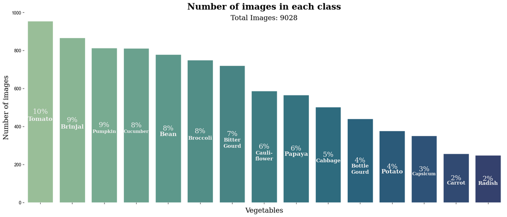

```python
# Plot a bar chart of the number of images in each class
fig, ax = plt.subplots(figsize=(20, 8))
sns.set_context('notebook',  font_scale=1.2)
sns.set_style('whitegrid', {'grid.color': '0.9'})

plt.box(False)

labels = labels[counts.argsort()[::-1]]
counts = counts[counts.argsort()[::-1]]

counts_df = pd.DataFrame(counts, columns=['counts'], index=labels)

sns.barplot(counts_df, x=counts_df.index, y='counts', palette='crest', hue=counts_df.index, ax=ax)

# Get actual counts of each class
tomato = counts_df.loc['Tomato']['counts']
brinjal = counts_df.loc['Brinjal']['counts']
pumpkin = counts_df.loc['Pumpkin']['counts']
cucumber = counts_df.loc['Cucumber']['counts']
bean = counts_df.loc['Bean']['counts']
broccoli = counts_df.loc['Broccoli']['counts']
bitterGourd = counts_df.loc['Bitter_Gourd']['counts']
cauliflower = counts_df.loc['Cauliflower']['counts']
papaya = counts_df.loc['Papaya']['counts']
cabbage = counts_df.loc['Cabbage']['counts']
bottleGourd = counts_df.loc['Bottle_Gourd']['counts']
potato = counts_df.loc['Potato']['counts']
capsicum = counts_df.loc['Capsicum']['counts']
carrot = counts_df.loc['Carrot']['counts']
raddish = counts_df.loc['Radish']['counts']
total = counts_df['counts'].sum()

# Annotations

# Tomato
plt.annotate(f"{int((tomato/total)*100)}%", xy=(0, tomato//2), fontfamily='serif', fontsize=16,
                ha='center', va='center', color='#eeeeee')
plt.annotate(f"Tomato", xy=(0, tomato//2 - tomato//24), fontfamily='serif', fontsize=14, fontweight='bold',
                va='center', ha='center', color="#eeeeee")

# Brinjal
plt.annotate(f"{int((brinjal/total)*100)}%", xy=(1, brinjal//2), fontfamily='serif', fontsize=16,
                ha='center', va='center', color='#eeeeee')
plt.annotate(f"Brinjal", xy=(1, brinjal//2 - brinjal//24), fontfamily='serif', fontsize=14, fontweight='bold',
                va='center', ha='center', color="#eeeeee")

# Pumpkin
plt.annotate(f"{int((pumpkin/total)*100)}%", xy=(2, pumpkin//2), fontfamily='serif', fontsize=16,
                ha='center', va='center', color='#eeeeee')
plt.annotate(f"Pumpkin", xy=(2, pumpkin//2 - pumpkin//24), fontfamily='serif', fontsize=11, fontweight='bold',
                va='center', ha='center', color="#eeeeee")

# Cucumber
plt.annotate(f"{int((cucumber/total)*100)}%", xy=(3, cucumber//2), fontfamily='serif', fontsize=16,
                ha='center', va='center', color='#eeeeee')
plt.annotate(f"Cucumber", xy=(3, cucumber//2 - cucumber//24), fontfamily='serif', fontsize=10, fontweight='bold',
                va='center', ha='center', color="#eeeeee")

# Bean
plt.annotate(f"{int((bean/total)*100)}%", xy=(4, bean//2), fontfamily='serif', fontsize=16,
                ha='center', va='center', color='#eeeeee')
plt.annotate(f"Bean", xy=(4, bean//2 - bean//24), fontfamily='serif', fontsize=14, fontweight='bold',
                va='center', ha='center', color="#eeeeee")

# Broccoli
plt.annotate(f"{int((broccoli/total)*100)}%", xy=(5, broccoli//2), fontfamily='serif', fontsize=16,
                ha='center', va='center', color='#eeeeee')
plt.annotate(f"Broccoli", xy=(5, broccoli//2 - broccoli//20), fontfamily='serif', fontsize=12, fontweight='bold',
                va='center', ha='center', color="#eeeeee")

# Bitter Gourd
plt.annotate(f"{int((bitterGourd/total)*100)}%", xy=(6, bitterGourd//2), fontfamily='serif', fontsize=16,
                ha='center', va='center', color='#eeeeee')
plt.annotate(f"Bitter\nGourd", xy=(6, bitterGourd//2 - bitterGourd//15), fontfamily='serif', fontsize=12, fontweight='bold',
                va='center', ha='center', color="#eeeeee")

# Cauliflower
plt.annotate(f"{int((cauliflower/total)*100)}%", xy=(7, cauliflower//2), fontfamily='serif', fontsize=16,
                ha='center', va='center', color='#eeeeee')
plt.annotate(f"Cauli-\nflower", xy=(7, cauliflower//2 - cauliflower//12), fontfamily='serif', fontsize=12, fontweight='bold',
                va='center', ha='center', color="#eeeeee")

# Papaya
plt.annotate(f"{int((papaya/total)*100)}%", xy=(8, papaya//2), fontfamily='serif', fontsize=16,
                ha='center', va='center', color='#eeeeee')
plt.annotate(f"Papaya", xy=(8, papaya//2 - papaya//20), fontfamily='serif', fontsize=14, fontweight='bold',
                va='center', ha='center', color="#eeeeee")

# Cabbage
plt.annotate(f"{int((cabbage/total)*100)}%", xy=(9, cabbage//2), fontfamily='serif', fontsize=16,
                ha='center', va='center', color='#eeeeee')
plt.annotate(f"Cabbage", xy=(9, cabbage//2 - cabbage//16), fontfamily='serif', fontsize=12, fontweight='bold',
                va='center', ha='center', color="#eeeeee")

# Bottle Gourd
plt.annotate(f"{int((bottleGourd/total)*100)}%", xy=(10, bottleGourd//2), fontfamily='serif', fontsize=16,
                ha='center', va='center', color='#eeeeee')
plt.annotate(f"Bottle\nGourd", xy=(10, bottleGourd//2 - bottleGourd//10), fontfamily='serif', fontsize=12, fontweight='bold',
                va='center', ha='center', color="#eeeeee")

# Potato
plt.annotate(f"{int((potato/total)*100)}%", xy=(11, potato//2), fontfamily='serif', fontsize=16,
                ha='center', va='center', color='#eeeeee')
plt.annotate(f"Potato", xy=(11, potato//2 - potato//14), fontfamily='serif', fontsize=14, fontweight='bold',
                va='center', ha='center', color="#eeeeee")

# Capsicum
plt.annotate(f"{int((capsicum/total)*100)}%", xy=(12, capsicum//2), fontfamily='serif', fontsize=16,
                ha='center', va='center', color='#eeeeee')
plt.annotate(f"Capsicum", xy=(12, capsicum//2 - capsicum//14), fontfamily='serif', fontsize=10, fontweight='bold',
                va='center', ha='center', color="#eeeeee")

# Carrot
plt.annotate(f"{int((carrot/total)*100)}%", xy=(13, carrot//2), fontfamily='serif', fontsize=16,
                ha='center', va='center', color='#eeeeee')
plt.annotate(f"Carrot", xy=(13, carrot//2 - carrot//10), fontfamily='serif', fontsize=12, fontweight='bold',
                va='center', ha='center', color="#eeeeee")

# Radish
plt.annotate(f"{int((raddish/total)*100)}%", xy=(14, raddish//2), fontfamily='serif', fontsize=16,
                ha='center', va='center', color='#eeeeee')
plt.annotate(f"Radish", xy=(14, raddish//2 - raddish//10), fontfamily='serif', fontsize=12, fontweight='bold',
                va='center', ha='center', color="#eeeeee")


plt.annotate(f"Total Images: {total}", xy=(7, 970), fontfamily='serif', fontsize=16,
                ha='center', va='center', color='#000000')

plt.title('Number of images in each class', fontfamily='serif', fontsize=20, fontweight='bold')
ax.set_xticklabels([])
ax.set_xlabel('Vegetables', fontfamily='serif', fontsize=16)
ax.set_ylabel('Number of images', fontfamily='serif', fontsize=16)

plt.show()
```

**Observations**:

- From the chart, we can see that the number of images for each vegetable is not balanced with some having as many as 900 images and others only having 200 images
- As such, we must find a way to handle this later during model training

#### Image Pixel Distribution

Lets take a look at the pixel intensity and to get a better understanding of the images

```python
print("31x31 Images")
train_31_imgs = np.array([img[0].numpy() for img in train_31])
print("Max: ", np.max(train_31_imgs))
print("Min: ", np.min(train_31_imgs))

print('\n')

print("128x128 Images")
train_128_imgs = np.array([img[0].numpy() for img in train_128])
print("Max: ", np.max(train_128_imgs))
print("Min: ", np.min(train_128_imgs))
```

```
31x31 Images
Max:  255.0
Min:  0.0


128x128 Images
Max:  255.0
Min:  0.0
```

As expected, our piexels have values between 0 and 255 for both the 31x31 and 128x128 images

```python
print("31x31 Images")
print("Mean: ", (np.mean(train_31_imgs)))
print("Stdev: ", np.std(train_31_imgs))

print('\n')

print("128x128 Images")
print("Mean: ", np.mean(train_128_imgs))
print("Stdev: ", np.std(train_128_imgs))
```

```
31x31 Images
Mean:  114.34133
Stdev:  55.387924


128x128 Images
Mean:  114.33357
Stdev:  55.363987
```

From the mean pixel value, we see that the average pixel is not very bright but there is some variation in the pixel intensity.

Another interesting thing to note is that the mean average pixel value and mean variation in pixel is not very different between the 31x31 images and the 128x128 images

#### Image Averaging

Image Averaging is the process of stacking multiple photos on top of each other and averaging them together. The main purpose is to see the noise of the image as well as observe all images in the dataset

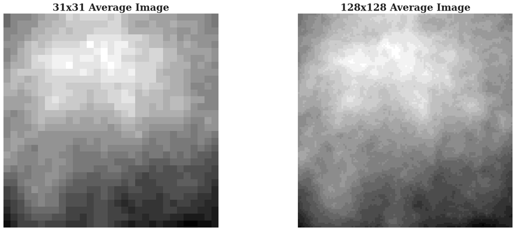

```python
# Subplot
fig, ax = plt.subplots(1, 2, figsize=(20, 8))

# 31x31
ax[0].set_title("31x31 Average Image", fontfamily='serif', fontsize=20, fontweight='bold')
ax[0].imshow(np.mean(train_31_imgs, axis=0).astype('uint16'), cmap='gray')
ax[0].axis('off')

# 128x128
ax[1].set_title("128x128 Average Image", fontfamily='serif', fontsize=20, fontweight='bold')
ax[1].imshow(np.mean(train_128_imgs, axis=0).astype('uint16'), cmap='gray')
ax[1].axis('off')

plt.show()
```

**Observations**:

- From both images we can see that generally, the brighter pixels are on top and not exactly in the middle. This means that the images are not all zoomed in so that the entire image only contains the specific vegetable
- It seems that although the 31x31 image is not as clear compared to the 128x128 image, there are still some similar features which can be discerned when comparing the two images

Now let us see what is the average image for each class label to see how similar each image is

```python
def plot_avg_images(data, n_rows=3, n_cols=5, cmap=None, title=""):
    fig, ax = plt.subplots(n_rows, n_cols, figsize=(24, 10))

    X_train = np.array([img[0].numpy() for img in data])
    y_train = np.array([label[1].numpy() for label in data])

    plt.suptitle(title, fontfamily='serif', fontsize=20, fontweight='bold')

    seen_labels = set()
    num_plots = 0

    try_unbatch(data)

    # data.take takes a random batch of images with size specified
    for idx, subplot in enumerate(ax.ravel()):
            avg_image = np.mean(X_train[np.squeeze(y_train == idx)], axis=0) / 255
            subplot.imshow(avg_image, cmap='gray')
            subplot.set_title(classes[idx], fontfamily='serif', fontsize=12, fontweight='bold')
            subplot.axis('off')
```

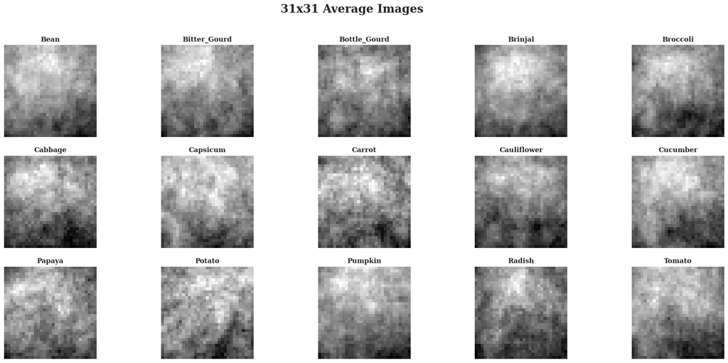

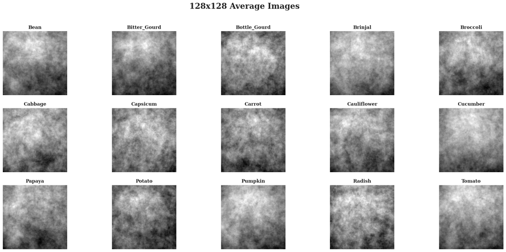

```python
plot_avg_images(train_31, title="31x31 Average Images")
plot_avg_images(train_128, title="128x128 Average Images")
```

**Observation**:

- From the average image of each class label, it is not very clear for us to see and predict what the image is
- This suggests that there is quite a significant amount of variation within the images of all 15 classes of vegetables
- To reduce the impact of variations and emphasize on the more imporatant features, we can try and apply techniques such as histogram equalization or contrast stretching

### **Model Training**

#### Part 1: Training the model for 128x128 images

##### Baseline Model (CNN)

CNN Layers Explained

`Convolutional Layer`

A convolutional layer is the core building block of the CNN. This layer performs a dot product between two matrices where one matrix is the set of learnable parameters known as a **kernel**/**filters**. The kernel is spatially smaller than an image but is more in depth. During the forward pass, the kernel slides across the height and width of the image-producing the image representation of that region.

In keras, the *kernel_size* parameter referes to the size of these convolution kernels. It is usually specified as a tuple where (3,3) would mean that the kernel is a 3x3 matrix. The *filter* parameter refers to the number of different kernels that are used in the convolution operation so filters=100 means that 100 different 3x3 kernels are used to conlve with the input data.

The sliding size of the kernel is called a **stride**. In keras, the stride of a kernel can be specified using *strides*.

Everytime we apply a convolution operator, our image shrinks which can cause us to lose a lot of information because of image shrinking. To fix this issue, we can use **padding** where we add layers of zeros or other value outside the actual data of our image. In keras, we can specify to use padding using the parameter *padding* and a value of 'same'.

Finally, we would have to specify an activation function for each convolution layer

For a convolutional layer, the output activation map will have the following dimensions $$W_{out} = \frac{W_{in} - K + 2P}{S} + 1$$ $$H_{out} = \frac{H_{in} - K + 2P}{S} + 1$$

Given

- an image of dimensions $W_{in} X H_{in}$
- a filter of dimension $F$ x $F$
- Stride $S$ and padding $P$

`Pooling Layer`

A pooling layer is another essential component of a Convolutional Neural Network (CNN). It plays a critical role in reducing the spatial dimensions of the input data, which helps to decrease the computational complexity of the model.

The pooling operation involves sliding a two-dimensional filter over each channel of the feature map and summarizing the features lying within the region covered by the filter. This operation helps to retain the most important information while reducing the dimensionality of the data

In Keras, the pooling operation is typically performed using a MaxPooling2D or AveragePooling2D layer. The size of the pooling window and the stride can be specified using the *pool_size* and *strides* parameters respectively

`Fully Connected Layer`

The Fully Connected (FC) layer is used to connect the neurons between two different layers. These layers are usually placed before the output layer and form the last few layers of a CNN Architecture

The input image from the previous layers are flattened and fed to the FC layer where the classification process begins to take place. In keras, a fully connected layer can be used using *Dense* with the number of neurons in the fully connected layer and the activation function

`Dropout`

Overfitting occurs when a particular model learns to train on the noise from the training set of the data and does not generalise well to new data. To overcome this problem, a dropout layer is utilised where a few neurons are dropped from the neural network during the training process so that the model learns not to overely on just a few neurons. In keras, this can be specified with the *Dropout* layer and the percentage of neurons to drop

CNN Baseline Model Architecture

1. Convolutional Layer
- Filters: 64
- Kernel Size: (3, 3)
- Strides: (2, 2)
- Padding: 'same'
- Activation Function: 'relu'
2. MaxPooling
- Pool Size: (2, 2)
3. Convolutional Layer
- Filters: 128
- Kernel Size: (3, 3)
- Strides: (1, 1)
- Padding: 'same'
- Activation Function: 'relu'
4. MaxPooling
- Pool Size: (2, 2)
5. Convolutional Layer
- Filters: 256
- Kernel Size: (3, 3)
- Strides: (1, 1)
- Padding: 'same'
- Activation Function: 'relu'
6. MaxPooling
- Pool Size: (2, 2)
7. Fully Connected Layer
- Neurons: 128
- Activation Function: 'relu'
8. Output Layer
- Neurons: 15 (number of classes)
- Activation Function: 'softmax'

Optimizer: Adam Epochs: 100

```python
# Model with data augmentation but no balancing
BaselineModel = Sequential(
    name="BaselineModel",
    layers=[
    Conv2D(filters=64, kernel_size=3, strides=2, padding='same', activation='relu', input_shape=(128, 128, 1)),
    MaxPooling2D(pool_size=2),

    Conv2D(filters=128, kernel_size=3, strides=1, padding='same', activation='relu'),
    MaxPooling2D(pool_size=2),

    Conv2D(filters=256, kernel_size=3, strides=1, padding='same', activation='relu'),
    MaxPooling2D(pool_size=2),

    Flatten(),
    Dropout(0.6),
    Dense(128, activation='relu'),
    Dense(num_classes, activation='softmax')
])

BaselineModel.compile(
    optimizer=Adam(),
    loss='sparse_categorical_crossentropy',
    metrics=['accuracy']
)

BaselineModel.build(input_shape=(None, 128, 128, 1))

BaselineModel.summary()

epochs = 100
BaselineModel_history = BaselineModel.fit(
    train_128.batch(batch_size),
    validation_data=val_128.batch(batch_size),
    epochs=epochs
)
```

```
Model: "BaselineModel"
_________________________________________________________________
 Layer (type)                Output Shape              Param #
=================================================================
 conv2d (Conv2D)             (None, 64, 64, 64)        640

 max_pooling2d (MaxPooling2D  (None, 32, 32, 64)       0
 )

 conv2d_1 (Conv2D)           (None, 32, 32, 128)       73856

 max_pooling2d_1 (MaxPooling  (None, 16, 16, 128)      0
 2D)
_________________________________________________________________
 Layer (type)                Output Shape              Param #
=================================================================
 conv2d (Conv2D)             (None, 64, 64, 64)        640

 max_pooling2d (MaxPooling2D  (None, 32, 32, 64)       0
 )

 conv2d_1 (Conv2D)           (None, 32, 32, 128)       73856

 max_pooling2d_1 (MaxPooling  (None, 16, 16, 128)      0
 2D)

 conv2d_2 (Conv2D)           (None, 16, 16, 256)       295168

 max_pooling2d_2 (MaxPooling  (None, 8, 8, 256)        0
 2D)

 flatten (Flatten)           (None, 16384)             0

 dropout (Dropout)           (None, 16384)             0

 dense (Dense)               (None, 128)               2097280

 dense_1 (Dense)             (None, 15)                1935

=================================================================
Total params: 2,468,879
Trainable params: 2,468,879
Non-trainable params: 0
_________________________________________________________________
```

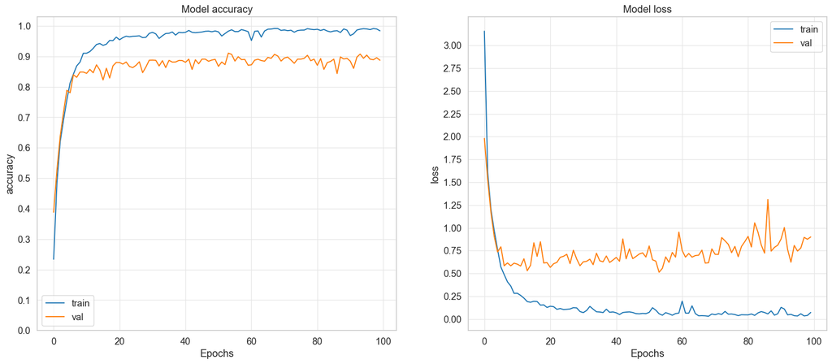

```python
plot_history(BaselineModel, BaselineModel_history, epochs)
```

**Observations**:

- The base model already has a very good performance with validation accruracy close to 90%
- There is quite a bit of fluctuation in the learning curve for both the train and validation sets. To combat this, we can try lowering the learning rate
- However, there is still quite a lot of improvements to be made for the model since the model loss is still quite high at around 1.0

Save the performance of our models for comparison later in a dataframe

```python
perf_128_models = pd.DataFrame()

perf_128_models = save_model_performance(perf_128_models, BaselineModel, BaselineModel_history, "Original")
display(perf_128_models)
```

|  | Data | Mean loss | Mean accuracy | Mean val_loss | Mean val_accuracy |
| --- | --- | --- | --- | --- | --- |
| BaselineModel | Original | 0.177107 | 0.948607 | 0.74933 | 0.865227 |

##### Adding Additional Data using Data Augmentation

In order to try and further improve the performance of our baseline model, we can try to add in additional data into our dataset by using data augmentation. Data Augmentation is a method to reduce the variance of a model by imposing random transformations on the data for training

The first augmentation that will be done will be rescaling the pixels in the images from a range of [0, 255] to a range of [0, 1]

```python
rescale = keras.Sequential(
    name="data_rescaling",
    layers=[
        Rescaling(1.0/255), # Value Preprocessing
    ]
)
```

Instead of directly applying the rescale model to our training dataset, we will be using it as the first layer in our later model so that the rescaling is applied in the model before the input is fed in

```python
# Split the dataset into X_train and y_train
data = [(img.numpy(), classes[labels]) for img, labels in train_128]

# Convert the list to numpy arrays
X_train = np.array([img for img, label in data])
y_train = np.array([label for img, label in data])
```

There are many different types of Image Data Augmentations but in this case, we will be using:

- Rescaling (refer to above)
- Rotation
- Zooming
- Shifting
- Shearing
- Flipping

Reasons for using each Data Augmentation

`Rotation`

Rotation is applied to train a model to avoid overfitting by introducing diversity in the data. The main advantage of rotation is that it doesn't change the meaning of the data entirely if applied to a certain extent.

`Zooming`

Image zooming randomly zooms the image in and adds new pixel values around the image or interpolates pixel values respectively. Image zooming is used to make the model more robust to changes in scale and perspective and better equipped to handle variations in objects sizes.

`Shifting`

Shifting or translation is used to make the object off-center from the image which ensures that the model learns to recognize patterns regardless of the object's exact location.

`Shearing`

Shearing involves changing the shape of an object by shifting each point within the object by a certain amount in a specified direction. Shearing helps the model generalize better to objects that may be viewed from different angles or perspectives

`Flipping`

Flipping is used to increase the dataset's size during training and is often applied randomly on images to reduce overfitting and introduce diversity in the data

Custom Data Augmentation

`Center Crop`

*Implementation*

Other than the data augmentation methods from keras, we can use custom data augmentation methods. In this case, we will be building a custom function to crop the image and get the center based on the specified crop_scale. The function will not be called all of the time but only p% of the time.

*Technique Explanation*

Center cropping is quite similar to random cropping. However, the main difference between center cropping and random cropping is that the cropping only results in the center of the image for center cropping. The main reason for using this technique is when the center portion of the image contains more information than the center which forces the model to learn from the center portion of the image rather than the corners

```python
# Custom Data Augmentation function
def center_crop_img(img, crop_scale=0.95, p=0.8):
    """
    Center crop an image

    Parameters
    ----------
    img : ndarray
        Image to be center cropped
    crop_scale : float (from 0 to 1)
        Scale of the crop
    p : float (from 0 to 1)
        Probability of applying the augmentation
    """

    # Check crop_scale and p are between 0 and 1
    assert 0 < crop_scale <= 1, "crop_scale must be in the range (0, 1]"
    assert 0 <= p <= 1, "p must be in the range [0, 1]"

    # Use random choice to decide whether to apply the augmentation
    if random.random() > p:
        return img

    # Get crop size from crop_scale
    height, width = img.shape[0], img.shape[1]
    crop_size = (int(height*crop_scale), int(width*crop_scale))

    dy, dx = crop_size
    x = (width - dx) // 2
    y = (height - dy) // 2

    img = img[y:(y+dy), x:(x+dx)]

    # Resize back to original size
    img = tf.image.resize(img, (height, width), method='nearest')


    return img
```

```python
from keras.preprocessing.image import ImageDataGenerator
datagen = ImageDataGenerator(
        rotation_range=40, # rotation
        zoom_range=0.2, # zoom
        width_shift_range=0.2, # horizontal shift
        height_shift_range=0.2, # vertical shift
        shear_range=0.2, # shear
        horizontal_flip=True, # horizontal flip
        fill_mode = 'reflect', # fill mode
        preprocessing_function=center_crop_img # center crop
)

# Generate images in batches of 256
aug_iter = datagen.flow(x=X_train, y=y_train, batch_size=256)
print("Previous shape: ", X_train.shape, y_train.shape)

# Generate batch of images
for i in range(60):
        image, label=next(aug_iter)

        X_train = np.append(X_train, image, axis=0)
        y_train = np.append(y_train, label)

print("New shape: ", X_train.shape, y_train.shape)
```

```
Previous shape:  (9028, 128, 128, 1) (9028,)
New shape:  (24200, 128, 128, 1) (24200,)
```

```python
class_to_index = {class_name: index for index, class_name in enumerate(classes)}
y_train_int = np.array([class_to_index[label] for label in y_train])
```

```python
# Join x_train and y_train together and add it back to the train_128 dataset
aug_train_128 = tf.data.Dataset.from_tensor_slices((X_train, y_train_int))
```

```python
aug_counter = {}
for img, label in aug_train_128:
    if classes[label] not in aug_counter:
        aug_counter[classes[label]] = 1
    else:
        aug_counter[classes[label]] += 1

labels, counts = np.array(list(aug_counter.keys())), np.array(list(aug_counter.values()))

labels = labels[counts.argsort()[::-1]]
counts = counts[counts.argsort()[::-1]]

counts_df = pd.DataFrame(counts, columns=['counts'], index=labels)

display(counts_df)
```

|  | counts |
| --- | --- |
| Tomato | 2567 |
| Brinjal | 2316 |
| Cucumber | 2177 |
| Pumpkin | 2166 |
| Bean | 2089 |
| Broccoli | 2044 |
| Bitter_Gourd | 1928 |
| Cauliflower | 1574 |
| Papaya | 1496 |
| Cabbage | 1345 |
| Bottle_Gourd | 1187 |
| Potato | 1014 |
| Capsicum | 947 |
| Carrot | 690 |
| Radish | 660 |

#### Improvements Made for DataAugModel:

```python
# Model with data augmentation but no balancing
DataAugModel = Sequential(
    name="DataAugModel",
    layers=[

    rescale,

    Conv2D(filters=64, kernel_size=3, strides=2, padding='same', activation='relu', input_shape=(128, 128, 1)),
    MaxPooling2D(pool_size=2),

    Conv2D(filters=128, kernel_size=3, strides=1, padding='same', activation='relu'),
    MaxPooling2D(pool_size=2),

    Conv2D(filters=256, kernel_size=3, strides=1, padding='same', activation='relu'),
    MaxPooling2D(pool_size=2),

    Flatten(),
    Dropout(0.6),
    Dense(128, activation='relu'),
    Dense(num_classes, activation='softmax')
])

DataAugModel.compile(
    optimizer=Adam(learning_rate=0.000_25),
    loss='sparse_categorical_crossentropy',
    metrics=['accuracy']
)

DataAugModel.build(input_shape=(None, 128, 128, 1))

DataAugModel.summary()

epochs = 100
DataAugModel_history = DataAugModel.fit(
    aug_train_128.batch(batch_size),
    validation_data=val_128.batch(batch_size),
    epochs=epochs
)
```

```
Model: "DataAugModel"
_________________________________________________________________
 Layer (type)                Output Shape              Param #
=================================================================
 data_rescaling (Sequential)  (None, 128, 128, 1)      0

 conv2d_3 (Conv2D)           (None, 64, 64, 64)        640

 max_pooling2d_3 (MaxPooling  (None, 32, 32, 64)       0
 2D)

 conv2d_4 (Conv2D)           (None, 32, 32, 128)       73856

 max_pooling2d_4 (MaxPooling  (None, 16, 16, 128)      0
_________________________________________________________________
 Layer (type)                Output Shape              Param #
=================================================================
 data_rescaling (Sequential)  (None, 128, 128, 1)      0

 conv2d_3 (Conv2D)           (None, 64, 64, 64)        640

 max_pooling2d_3 (MaxPooling  (None, 32, 32, 64)       0
 2D)

 conv2d_4 (Conv2D)           (None, 32, 32, 128)       73856

 max_pooling2d_4 (MaxPooling  (None, 16, 16, 128)      0
 2D)

 conv2d_5 (Conv2D)           (None, 16, 16, 256)       295168

 max_pooling2d_5 (MaxPooling  (None, 8, 8, 256)        0
 2D)

 flatten_1 (Flatten)         (None, 16384)             0

 dropout_1 (Dropout)         (None, 16384)             0

 dense_2 (Dense)             (None, 128)               2097280

 dense_3 (Dense)             (None, 15)                1935

=================================================================
Total params: 2,468,879
Trainable params: 2,468,879
Non-trainable params: 0
_________________________________________________________________
```

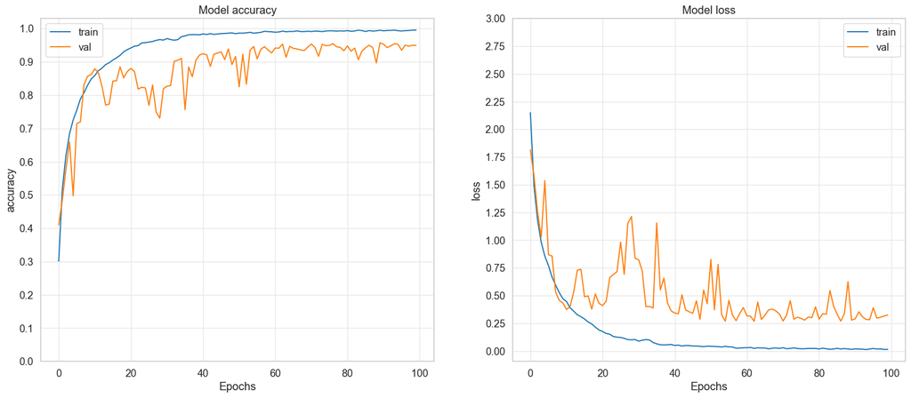

```python
plot_history(DataAugModel, DataAugModel_history, epochs)
```

```python
perf_128_models = save_model_performance(perf_128_models, DataAugModel, DataAugModel_history, "Augmented")
display(perf_128_models)
```

|  | Data | Mean loss | Mean accuracy | Mean val_loss | Mean val_accuracy |
| --- | --- | --- | --- | --- | --- |
| BaselineModel | Original | 0.177107 | 0.948607 | 0.749330 | 0.865227 |
| DataAugModel | Augmented | 0.164322 | 0.946507 | 0.509775 | 0.877827 |

##### Improving Architecture of CNN Model

In order to try and improve our models, here are some things we can change in our model's architecture:

- Increase number of convolutional layers: In order to try and capture more complex features, we can try to increase the number of convolutional layers being used in the model from 3 to 5 with the two additional layers sharing a max pooling layer
- Increase kernel size: In order to try and detect larger features, we can try and increase the kernel size of our model for the first few layers instead of just using a consistent kernel size of (3, 3)
- Increase number of FC layers: Instead of just using one FC layer, we can use two FC layers
- Add BatchNormalization: In order to try and reduce overfitting, we can use batch normalization to make the model more stable by normalizing the inputs through re-centering and re-scaling

With these new chages, here is the new architecture of the model

CNN Improved Model Architecture

1. Convolutional Layer
- Filters: 32
- Kernel Size: (7, 7)
- Strides: (2, 2)
- Padding: 'same'
- Activation Function: 'relu'
2. MaxPooling
- Pool Size: (2, 2)
3. Convolutional Layer
- Filters: 64
- Kernel Size: (5, 5)
- Strides: (2, 2)
- Padding: 'same'
- Activation Function: 'relu'
4. MaxPooling
- Pool Size: (2, 2)
5. Convolutional Layer
- Filters: 128
- Kernel Size: (3, 3)
- Strides: (1, 1)
- Padding: 'same'
- Activation Function: 'relu'
6. MaxPooling
- Pool Size: (2, 2)
7. Convolutional Layer
- Filters: 256
- Kernel Size: (3, 3)
- Strides: (1, 1)
- Padding: 'same'
- Activation Function: 'relu'
8. Convolutional Layer
- Filters: 512
- Kernel Size: (3, 3)
- Strides: (1, 1)
- Padding: 'same'
- Activation Function: 'relu'
9. MaxPooling
- Pool Size: (2, 2)
10. Fully Connected Layer
- Neurons: 256
- Activation Function: 'relu'
11. Fully Connected Layer
- Neurons: 128
- Activation Function: 'relu'
12. Batch Normalization
13. Output Layer
- Neurons: 15 (number of classes)
- Activation Function: 'softmax'

Optimizer: Adam (learning rate = 0.000,25) Epochs: 100

#### Improvements made for ImprovedArchModel:

```python
# Model with data augmentation but no balancing
ImprovedArchModel = Sequential(
    name="ImprovedArchitectureModel",
    layers=[
    # Preprocessing Layer
    rescale,

    Conv2D(filters=32, kernel_size=7, strides=2, padding='same', activation='relu', input_shape=(128, 128, 1)),
    MaxPooling2D(pool_size=2),

    Conv2D(filters=64, kernel_size=5, strides=2, padding='same', activation='relu'),
    MaxPooling2D(pool_size=2),

    Conv2D(filters=128, kernel_size=3, strides=1, padding='same', activation='relu'),
    MaxPooling2D(pool_size=2),

    Conv2D(filters=256, kernel_size=3, strides=1, padding='same', activation='relu'),
    Conv2D(filters=512, kernel_size=3, strides=1, padding='same', activation='relu'),
    MaxPooling2D(pool_size=2),

    Flatten(),
    Dropout(0.6),
    Dense(256, activation='relu'),
    Dropout(0.6),
    Dense(128, activation='relu'),
    BatchNormalization(),
    Dense(num_classes, activation='softmax')
])

ImprovedArchModel.compile(
    optimizer=Adam(learning_rate=0.000_25),
    loss='sparse_categorical_crossentropy',
    metrics=['accuracy']
)

ImprovedArchModel.build(input_shape=(None, 128, 128, 1))

ImprovedArchModel.summary()

epochs = 100
ImprovedArchModel_history = ImprovedArchModel.fit(
    aug_train_128.batch(batch_size),
    validation_data=val_128.batch(batch_size),
    epochs=epochs
)
```

```
Model: "ImprovedArchitectureModel"
_________________________________________________________________
 Layer (type)                Output Shape              Param #
=================================================================
 data_rescaling (Sequential)  (None, None, None, 1)    0

 conv2d_67 (Conv2D)          (None, 64, 64, 32)        1600
_________________________________________________________________
 Layer (type)                Output Shape              Param #
=================================================================
 data_rescaling (Sequential)  (None, None, None, 1)    0

 conv2d_67 (Conv2D)          (None, 64, 64, 32)        1600

 max_pooling2d_60 (MaxPoolin  (None, 32, 32, 32)       0
 g2D)

 conv2d_68 (Conv2D)          (None, 16, 16, 64)        51264

 max_pooling2d_61 (MaxPoolin  (None, 8, 8, 64)         0
 g2D)

 conv2d_69 (Conv2D)          (None, 8, 8, 128)         73856

 max_pooling2d_62 (MaxPoolin  (None, 4, 4, 128)        0
 g2D)

 conv2d_70 (Conv2D)          (None, 4, 4, 256)         295168

 conv2d_71 (Conv2D)          (None, 4, 4, 512)         1180160

 max_pooling2d_63 (MaxPoolin  (None, 2, 2, 512)        0
 g2D)

 flatten_21 (Flatten)        (None, 2048)              0

 dropout_26 (Dropout)        (None, 2048)              0

 dense_47 (Dense)            (None, 256)               524544

 dropout_27 (Dropout)        (None, 256)               0

 dense_48 (Dense)            (None, 128)               32896

 batch_normalization_13 (Bat  (None, 128)              512
 chNormalization)

 dense_49 (Dense)            (None, 15)                1935

=================================================================
Total params: 2,161,935
Trainable params: 2,161,679
Non-trainable params: 256
_________________________________________________________________
```

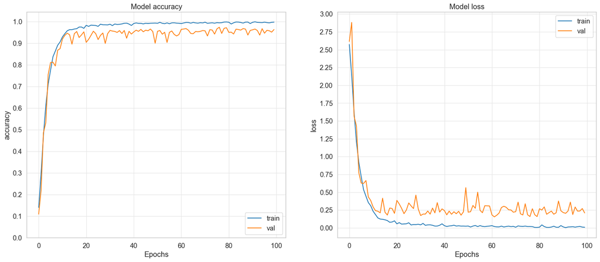

```python
plot_history(ImprovedArchModel, ImprovedArchModel_history, epochs)
```

**Observations**:

- With the addition of batch normalization, the learning curve for the validation set now no longer seems to fluctuate as much as before
- The improved architecture also seems to have improved the model's performance as it now converges to a validation accuracy of 90% much faster compared to before

```python
perf_128_models = save_model_performance(perf_128_models, ImprovedArchModel, ImprovedArchModel_history, "Augmented")
display(perf_128_models)
```

|  | Data | Mean loss | Mean accuracy | Mean val_loss | Mean val_accuracy |
| --- | --- | --- | --- | --- | --- |
| BaselineModel | Original | 0.177107 | 0.948607 | 0.749330 | 0.865227 |
| DataAugModel | Augmented | 0.164322 | 0.946507 | 0.509775 | 0.877827 |
| ImprovedArchitectureModel | Augmented | 0.142283 | 0.954847 | 0.348815 | 0.916610 |

##### Balancing Classes using Data Augmentation

As seen previously during the EDA, the number of images for each vegetable is not balanced with vegetables like tomato having as many as 900 images and other vegetables as radish only having 200 images

Instead of just adding data randomly using data augmentation to reduce the variance of our model, we can also use data augmentation to strategically add the number of images for each class such that it becomes more balanced. By doing so, our model will have enough training data for each class

```python
# Clear memory in space
# IMPORTANT STEP OTHERWISE DATASET CANNOT BE CREATED
del aug_train_128
```

```python
display(counter)
```

```
{'Bean': 780,
 'Capsicum': 351,
 'Bitter_Gourd': 720,
 'Potato': 377,
 'Cabbage': 503,
 'Papaya': 566,
 'Tomato': 955,
 'Cucumber': 812,
 'Bottle_Gourd': 441,
 'Pumpkin': 814,
 'Brinjal': 868,
 'Cauliflower': 587,
 'Broccoli': 750,
 'Carrot': 256,
 'Radish': 248}
```

```python
# Split the dataset into X_train and y_train
data = [(img.numpy(), classes[labels]) for img, labels in train_128]

# Convert the list to numpy arrays
X_train = np.array([img for img, label in data])
y_train = np.array([label for img, label in data])
```

In order to balance the classes, we will try to use increase the number of images for each class to a value of $N$ (where in this case, $N$ = 1750).

The eventual number of images generated however, will not be exactly the value $N$ but will be $$ImagesGenerated = {\lfloor \frac{N - CurrentNumberOfImages}{BatchSize} \rfloor} $$

When using ImageDataGenerator, generating the images one by one will be too slow so the images are usually generated in batches where a larger batch size will generate images quicker.

However, using a larger batch size means that we have less control over how many images get generated so the number of classes of each vegetable might be quite far from $N$.

As such, we will try to use a batch size of 32 so that we have some control over how many images get generated but the generation proces won't take too long

```python
# Split the training data into different classes
train_128_ds = {}

for vegetable in classes:
    mask = y_train == vegetable
    train_128_ds[vegetable] = X_train[mask]

aug_batch_size = 32

N = 1750

# Get the number of images to generate for each class and convert it to the nearest
num_batches = {vegetable: (N - counter[vegetable]) // aug_batch_size for vegetable in classes}

# Generate images for each class
for vegetable in classes:
    print(f"[{classes.index(vegetable)+1}/15] Generating Images for: {vegetable}")
    aug_iter = datagen.flow(x=train_128_ds[vegetable], y=[vegetable]*len(train_128_ds[vegetable]), batch_size=aug_batch_size)
    print("Initial Length: ", len(train_128_ds[vegetable]))
    print("Adding", num_batches[vegetable]*aug_batch_size, "Images")
    for i in range(num_batches[vegetable]):
        image, label=next(aug_iter)
        train_128_ds[vegetable] = np.append(train_128_ds[vegetable], image, axis=0)

    print("Current Length: ", len(train_128_ds[vegetable]))
    print('\n')

# Concatenate all the images together
X_train_bal = np.concatenate([train_128_ds[vegetable] for vegetable in classes], axis=0)
y_train_bal = np.concatenate([[vegetable]*len(train_128_ds[vegetable]) for vegetable in classes], axis=0)

print("New Shape: ", X_train_bal.shape, y_train_bal.shape)
```

```
[1/15] Generating Images for: Bean
Initial Length:  780
Adding 960 Images
Current Length:  1720


[2/15] Generating Images for: Bitter_Gourd
Initial Length:  720
Adding 1024 Images
Current Length:  1728


[3/15] Generating Images for: Bottle_Gourd
Initial Length:  441
Adding 1280 Images
Current Length:  1707


[4/15] Generating Images for: Brinjal
Initial Length:  868
Adding 864 Images
Current Length:  1732


[5/15] Generating Images for: Broccoli
Initial Length:  750
Adding 992 Images
Current Length:  1724


[6/15] Generating Images for: Cabbage
Initial Length:  503
Adding 1216 Images
Current Length:  1701


[7/15] Generating Images for: Capsicum
Initial Length:  351
Adding 1376 Images
Current Length:  1724
```

[output cut: 36 more lines]

```


[14/15] Generating Images for: Radish
Initial Length:  248
Adding 1472 Images
Current Length:  1680


[15/15] Generating Images for: Tomato
Initial Length:  955
Adding 768 Images
Current Length:  1723


New Shape:  (25759, 128, 128, 1) (25759,)
```

When using the balanced data augmentation method, we end up with 25,759 images which is just slightly more compared to the initial data augmentation method where we had around 24, 200 images

```python
# Convert the labels to integers
y_train_bal_int = np.array([class_to_index[label] for label in y_train_bal])
```

```python
# Randomly shuffle X_train_bal and y_train_bal in the same manner
from sklearn.utils import shuffle
X_train_bal, y_train_bal_int = shuffle(X_train_bal, y_train_bal_int, random_state=seed)
```

```python
# This won't run if the previous dataset is not deleted or if there is not enough memory
bal_train_128 = tf.data.Dataset.from_tensor_slices((X_train_bal, y_train_bal_int))
bal_train_128 = try_unbatch(bal_train_128)
```

```python
counter = {}
for img, label in bal_train_128:
    if classes[label] not in counter:
        counter[classes[label]] = 1
    else:
        counter[classes[label]] += 1

labels, counts = np.array(list(counter.keys())), np.array(list(counter.values()))
```

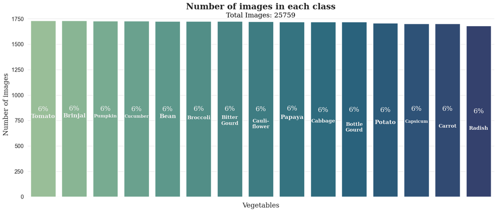

```python
# Plot a bar chart of the number of images in each class
fig, ax = plt.subplots(figsize=(20, 8))
sns.set_context('notebook',  font_scale=1.2)
sns.set_style('whitegrid', {'grid.color': '0.9'})

plt.box(False)

labels = labels[counts.argsort()[::-1]]
counts = counts[counts.argsort()[::-1]]

counts_df = pd.DataFrame(counts, columns=['counts'], index=labels)

sns.barplot(counts_df, x=counts_df.index, y='counts', palette='crest', hue=counts_df.index, ax=ax)

# Get actual counts of each class
tomato = counts_df.loc['Tomato']['counts']
brinjal = counts_df.loc['Brinjal']['counts']
pumpkin = counts_df.loc['Pumpkin']['counts']
cucumber = counts_df.loc['Cucumber']['counts']
bean = counts_df.loc['Bean']['counts']
broccoli = counts_df.loc['Broccoli']['counts']
bitterGourd = counts_df.loc['Bitter_Gourd']['counts']
cauliflower = counts_df.loc['Cauliflower']['counts']
papaya = counts_df.loc['Papaya']['counts']
cabbage = counts_df.loc['Cabbage']['counts']
bottleGourd = counts_df.loc['Bottle_Gourd']['counts']
potato = counts_df.loc['Potato']['counts']
capsicum = counts_df.loc['Capsicum']['counts']
carrot = counts_df.loc['Carrot']['counts']
raddish = counts_df.loc['Radish']['counts']
total = counts_df['counts'].sum()

# Annotations

# Tomato
plt.annotate(f"{int((tomato/total)*100)}%", xy=(0, tomato//2), fontfamily='serif', fontsize=16,
                ha='center', va='center', color='#eeeeee')
plt.annotate(f"Tomato", xy=(0, tomato//2 - tomato//24), fontfamily='serif', fontsize=14, fontweight='bold',
                va='center', ha='center', color="#eeeeee")

# Brinjal
plt.annotate(f"{int((brinjal/total)*100)}%", xy=(1, brinjal//2), fontfamily='serif', fontsize=16,
                ha='center', va='center', color='#eeeeee')
plt.annotate(f"Brinjal", xy=(1, brinjal//2 - brinjal//24), fontfamily='serif', fontsize=14, fontweight='bold',
                va='center', ha='center', color="#eeeeee")

# Pumpkin
plt.annotate(f"{int((pumpkin/total)*100)}%", xy=(2, pumpkin//2), fontfamily='serif', fontsize=16,
                ha='center', va='center', color='#eeeeee')
plt.annotate(f"Pumpkin", xy=(2, pumpkin//2 - pumpkin//24), fontfamily='serif', fontsize=11, fontweight='bold',
                va='center', ha='center', color="#eeeeee")

# Cucumber
plt.annotate(f"{int((cucumber/total)*100)}%", xy=(3, cucumber//2), fontfamily='serif', fontsize=16,
                ha='center', va='center', color='#eeeeee')
plt.annotate(f"Cucumber", xy=(3, cucumber//2 - cucumber//24), fontfamily='serif', fontsize=10, fontweight='bold',
                va='center', ha='center', color="#eeeeee")

# Bean
plt.annotate(f"{int((bean/total)*100)}%", xy=(4, bean//2), fontfamily='serif', fontsize=16,
                ha='center', va='center', color='#eeeeee')
plt.annotate(f"Bean", xy=(4, bean//2 - bean//24), fontfamily='serif', fontsize=14, fontweight='bold',
                va='center', ha='center', color="#eeeeee")

# Broccoli
plt.annotate(f"{int((broccoli/total)*100)}%", xy=(5, broccoli//2), fontfamily='serif', fontsize=16,
                ha='center', va='center', color='#eeeeee')
plt.annotate(f"Broccoli", xy=(5, broccoli//2 - broccoli//20), fontfamily='serif', fontsize=12, fontweight='bold',
                va='center', ha='center', color="#eeeeee")

# Bitter Gourd
plt.annotate(f"{int((bitterGourd/total)*100)}%", xy=(6, bitterGourd//2), fontfamily='serif', fontsize=16,
                ha='center', va='center', color='#eeeeee')
plt.annotate(f"Bitter\nGourd", xy=(6, bitterGourd//2 - bitterGourd//15), fontfamily='serif', fontsize=12, fontweight='bold',
                va='center', ha='center', color="#eeeeee")

# Cauliflower
plt.annotate(f"{int((cauliflower/total)*100)}%", xy=(7, cauliflower//2), fontfamily='serif', fontsize=16,
                ha='center', va='center', color='#eeeeee')
plt.annotate(f"Cauli-\nflower", xy=(7, cauliflower//2 - cauliflower//12), fontfamily='serif', fontsize=12, fontweight='bold',
                va='center', ha='center', color="#eeeeee")

# Papaya
plt.annotate(f"{int((papaya/total)*100)}%", xy=(8, papaya//2), fontfamily='serif', fontsize=16,
                ha='center', va='center', color='#eeeeee')
plt.annotate(f"Papaya", xy=(8, papaya//2 - papaya//20), fontfamily='serif', fontsize=14, fontweight='bold',
                va='center', ha='center', color="#eeeeee")

# Cabbage
plt.annotate(f"{int((cabbage/total)*100)}%", xy=(9, cabbage//2), fontfamily='serif', fontsize=16,
                ha='center', va='center', color='#eeeeee')
plt.annotate(f"Cabbage", xy=(9, cabbage//2 - cabbage//16), fontfamily='serif', fontsize=12, fontweight='bold',
                va='center', ha='center', color="#eeeeee")

# Bottle Gourd
plt.annotate(f"{int((bottleGourd/total)*100)}%", xy=(10, bottleGourd//2), fontfamily='serif', fontsize=16,
                ha='center', va='center', color='#eeeeee')
plt.annotate(f"Bottle\nGourd", xy=(10, bottleGourd//2 - bottleGourd//10), fontfamily='serif', fontsize=12, fontweight='bold',
                va='center', ha='center', color="#eeeeee")

# Potato
plt.annotate(f"{int((potato/total)*100)}%", xy=(11, potato//2), fontfamily='serif', fontsize=16,
                ha='center', va='center', color='#eeeeee')
plt.annotate(f"Potato", xy=(11, potato//2 - potato//14), fontfamily='serif', fontsize=14, fontweight='bold',
                va='center', ha='center', color="#eeeeee")

# Capsicum
plt.annotate(f"{int((capsicum/total)*100)}%", xy=(12, capsicum//2), fontfamily='serif', fontsize=16,
                ha='center', va='center', color='#eeeeee')
plt.annotate(f"Capsicum", xy=(12, capsicum//2 - capsicum//14), fontfamily='serif', fontsize=10, fontweight='bold',
                va='center', ha='center', color="#eeeeee")

# Carrot
plt.annotate(f"{int((carrot/total)*100)}%", xy=(13, carrot//2), fontfamily='serif', fontsize=16,
                ha='center', va='center', color='#eeeeee')
plt.annotate(f"Carrot", xy=(13, carrot//2 - carrot//10), fontfamily='serif', fontsize=12, fontweight='bold',
                va='center', ha='center', color="#eeeeee")

# Radish
plt.annotate(f"{int((raddish/total)*100)}%", xy=(14, raddish//2), fontfamily='serif', fontsize=16,
                ha='center', va='center', color='#eeeeee')
plt.annotate(f"Radish", xy=(14, raddish//2 - raddish//10), fontfamily='serif', fontsize=12, fontweight='bold',
                va='center', ha='center', color="#eeeeee")


plt.annotate(f"Total Images: {total}", xy=(7, 1780), fontfamily='serif', fontsize=16,
                ha='center', va='center', color='#000000')

plt.title('Number of images in each class', fontfamily='serif', fontsize=20, fontweight='bold')
ax.set_xticklabels([])
ax.set_xlabel('Vegetables', fontfamily='serif', fontsize=16)
ax.set_ylabel('Number of images', fontfamily='serif', fontsize=16)

plt.show()
```

**Observations**:

- Although the number of images are not exactly the same, they are close enough such that they all make up 6% of the data
- From the graph, we can now see that our training set is balanced

- Instead of feeding in the dataset with augmentation (aug_train_128), the **balanced** dataset with augmentation is fed into the model (bal_train_128). This increases our training slightly data from 24,200 to around 25,700 but more importantly, it balances the number of images to around 1750 for each class

```python
# Model with data augmentation and balancing
BalModel = Sequential(
    name="BalancedModel",
    layers=[
    # Preprocessing Layer
    rescale,

    Conv2D(filters=32, kernel_size=7, strides=2, padding='same', activation='relu', input_shape=(128, 128, 1)),
    MaxPooling2D(pool_size=2),

    Conv2D(filters=64, kernel_size=5, strides=2, padding='same', activation='relu'),
    MaxPooling2D(pool_size=2),

    Conv2D(filters=128, kernel_size=3, strides=1, padding='same', activation='relu'),
    MaxPooling2D(pool_size=2),

    Conv2D(filters=256, kernel_size=3, strides=1, padding='same', activation='relu'),

    Conv2D(filters=512, kernel_size=3, strides=1, padding='same', activation='relu'),
    MaxPooling2D(pool_size=2),

    Flatten(),
    Dropout(0.6),
    Dense(256, activation='relu'),
    Dropout(0.6),
    Dense(128, activation='relu'),
    BatchNormalization(),
    Dense(num_classes, activation='softmax')
])

BalModel.compile(
    optimizer=Adam(learning_rate=0.000_25),
    loss='sparse_categorical_crossentropy',
    metrics=['accuracy']
)

BalModel.build(input_shape=(None, 128, 128, 1))

BalModel.summary()

epochs = 100
BalModel_history = BalModel.fit(
    bal_train_128.batch(batch_size),
    validation_data=val_128.batch(batch_size),
    epochs=epochs,
)
```

```
Model: "BalancedModel"
_________________________________________________________________
 Layer (type)                Output Shape              Param #
=================================================================
 data_rescaling (Sequential)  (None, 128, 128, 1)      0

 conv2d_11 (Conv2D)          (None, 64, 64, 32)        1600

 max_pooling2d_10 (MaxPoolin  (None, 32, 32, 32)       0
 g2D)

 conv2d_12 (Conv2D)          (None, 16, 16, 64)        51264

_________________________________________________________________
 Layer (type)                Output Shape              Param #
=================================================================
 data_rescaling (Sequential)  (None, 128, 128, 1)      0

 conv2d_11 (Conv2D)          (None, 64, 64, 32)        1600

 max_pooling2d_10 (MaxPoolin  (None, 32, 32, 32)       0
 g2D)

 conv2d_12 (Conv2D)          (None, 16, 16, 64)        51264

 max_pooling2d_11 (MaxPoolin  (None, 8, 8, 64)         0
 g2D)

 conv2d_13 (Conv2D)          (None, 8, 8, 128)         73856

 max_pooling2d_12 (MaxPoolin  (None, 4, 4, 128)        0
 g2D)

 conv2d_14 (Conv2D)          (None, 4, 4, 256)         295168

 conv2d_15 (Conv2D)          (None, 4, 4, 512)         1180160

 max_pooling2d_13 (MaxPoolin  (None, 2, 2, 512)        0
 g2D)

 flatten_3 (Flatten)         (None, 2048)              0

 dropout_4 (Dropout)         (None, 2048)              0

 dense_7 (Dense)             (None, 256)               524544

 dropout_5 (Dropout)         (None, 256)               0

 dense_8 (Dense)             (None, 128)               32896

 batch_normalization_1 (Batc  (None, 128)              512
 hNormalization)

 dense_9 (Dense)             (None, 15)                1935

=================================================================
Total params: 2,161,935
Trainable params: 2,161,679
Non-trainable params: 256
_________________________________________________________________
```

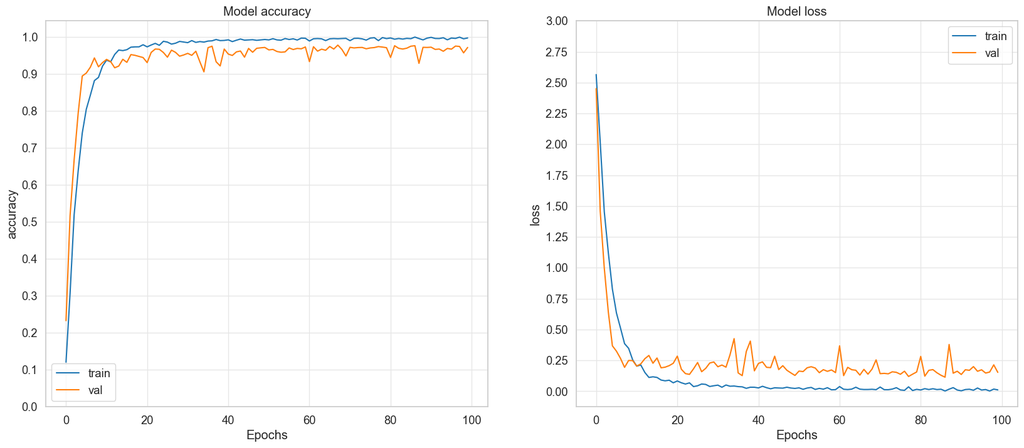

```python
plot_history(BalModel, BalModel_history, epochs)
```

**Observations**:

- Compared to the previous model, there is considerably lesser amount of fluctuations for model accuracy and model loss
- The model has a much more consistent performance with an accuracy of above 0.9
- In order to try and further reduce the fluctuations, we can try and use a learning rate scheduler to slowly decay the learning rate as the number of epochs increase

```python
perf_128_models = save_model_performance(perf_128_models, BalModel, BalModel_history, "Balanced Augmented")
display(perf_128_models)
```

|  | Data | Mean loss | Mean accuracy | Mean val_loss | Mean val_accuracy |
| --- | --- | --- | --- | --- | --- |
| BaselineModel | Original | 0.177107 | 0.948607 | 0.749330 | 0.865227 |
| DataAugModel | Augmented | 0.164322 | 0.946507 | 0.509775 | 0.877827 |
| ImprovedArchitectureModel | Augmented | 0.142283 | 0.954847 | 0.348815 | 0.916610 |
| BalancedModel | Balanced Augmented | 0.134344 | 0.956594 | 0.245093 | 0.940640 |

##### Using a Learning Rate Scheduler

Instead of using a constant learning rate throughout when training the model, we can use an adaptive learning rate that is being adjusted between epochs. In keras, this can be implemented with the `LearningRateScheduler` callback.

Common learning rate schedules include:

- Time-Based Decay
- Step-Based Decay
- Exponential Decay

Time-Based Decay

$$ \begin{equation} Rate\_{n} := Rate\_{n-1} \cdot \frac{1}{1 + Decay \cdot Epoch} \nonumber \end{equation} $$

In the above formula, the learning rate is being update by a factor of $\frac{1}{1 + Decay * Epoch}$ which is based on the rate of Decay specified and the number of Epochs the model has been through.

A common value of used for Decay is $$Decay = \frac{Rate\_{1}}{Epoch}$$

where the initial learning rate at the first epoch is used to calculate the Decay

In keras, a time-based decay learning rate scheduler can be defined as follows:

```
def timeDecay(epoch, lr):
    initial_lr = 0.000_25
    # + 1 to avoid division by 0
    decay = initial_lr/(epoch+1)
    return lr * 1/ (1 + decay * epoch)
```

Step-Based Decay

In step-based decay, the learning rate is systematically dropped by a factor every few epochs. The formula can be described as: $$ \begin{equation} Rate\_{n} := Rate\_{n-1} \cdot DropRate^{\lfloor \frac{Epoch}{EpochDrop} \rfloor} \nonumber \end{equation} $$

In keras, a step-based decay learning rate scheduler can be defined as follows:

```
def stepDecay(epoch, lr):
    dropRate = 0.5
    epochsDrop = 10.0
    return lr * np.power(dropRate, np.floor((1+epoch)/epochsDrop))
```

In the above formula, the learning rate is being dropped by the factor $DropRate$ after every $EpochDrop$ number of Epochs

Exponential-Based Decay

In Exponential Based Decay, the decay is defined as an exponential function of the number of epochs in the following equation: $$ \begin{equation} Rate\_{n} := Rate\_{n-1} \cdot e^{k \cdot Epoch} \nonumber \end{equation} $$

Exponential Based Decay tends to decay much faster compared to time-based decay

In keras, a exponential-based decay learning rate scheduler can be defined as follows:

```
def expDecay(epoch, lr):
    k = 0.001
    return lr * np.exp(-k * epoch)
```

**Comparing the Learning Rate for different schedulers:**

[figure not shown]

*Image from [neptune.ai](https://neptune.ai/blog/how-to-choose-a-learning-rate-scheduler)*

From the above image, we can see that exponential based decay decays much faster compared to time based decay initially but eventually, they will both decay to a very small learning where the change in learning rate becomes very small

As for step-based decay, it decays the slowest and it also does not decay to the point close to zero like time-based decay or exponential-decay

For the training of our model, we will be using time based decay. However based on testing, the decay is not fast enough so we can speed it up by an additional factor $k$

```python
def timeDecay(epoch, lr):
    initial_lr = 0.000_25
    # Use k to speed up the decay
    k = 100
    # + 1 to avoid division by 0
    decay = initial_lr/(epoch+1)
    return lr * 1/ (1 + k * decay * epoch)

learningRateScheduler = keras.callbacks.LearningRateScheduler(timeDecay)
```

```python
# Model with data augmentation but no balancing
FinalModel = Sequential(
    name="FinalModel",
    layers=[
    # Preprocessing Layer
    rescale,

    Conv2D(filters=32, kernel_size=7, strides=2, padding='same', activation='relu', input_shape=(128, 128, 1)),
    MaxPooling2D(pool_size=2),

    Conv2D(filters=64, kernel_size=5, strides=2, padding='same', activation='relu'),
    MaxPooling2D(pool_size=2),

    Conv2D(filters=128, kernel_size=3, strides=1, padding='same', activation='relu'),
    MaxPooling2D(pool_size=2),

    Conv2D(filters=256, kernel_size=3, strides=1, padding='same', activation='relu'),

    Conv2D(filters=512, kernel_size=3, strides=1, padding='same', activation='relu'),
    MaxPooling2D(pool_size=2),

    Flatten(),
    Dropout(0.6),
    Dense(128, activation='relu'),
    Dropout(0.6),
    Dense(64, activation='relu'),
    BatchNormalization(),
    Dense(num_classes, activation='softmax')
])

FinalModel.compile(
    optimizer=Adam(learning_rate=0.000_25),
    loss='sparse_categorical_crossentropy',
    metrics=['accuracy']
)

FinalModel.build(input_shape=(None, 128, 128, 1))

FinalModel.summary()

epochs = 100
FinalModel_history = FinalModel.fit(
    bal_train_128.batch(batch_size),
    validation_data=val_128.batch(batch_size),
    epochs=epochs,
    callbacks=[learningRateScheduler]
)
```

[output not shown]

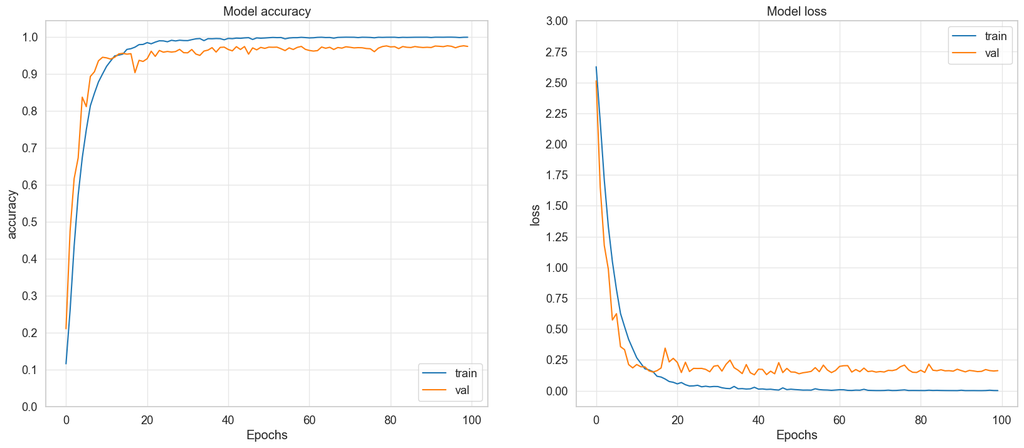

```python
plot_history(FinalModel, FinalModel_history, epochs)
```

**Observations**:

- From the learning curve, the fluctuations in the accuracy are pretty much non-existent
- The model loss has also improved significantly with it mostly being completely below 0.25 which is quite a good improvement compared to the model loss of around 1 from the baseline CNN
- With the learning rate scheduler, it seems that the learning rate decays to a very small value at the end as seen by how the accuracy at the end barely changes

```python
perf_128_models = save_model_performance(perf_128_models, FinalModel, FinalModel_history, "Balanced Augmented")
display(perf_128_models)
```

|  | Data | Mean loss | Mean accuracy | Mean val_loss | Mean val_accuracy |
| --- | --- | --- | --- | --- | --- |
| BaselineModel | Original | 0.177107 | 0.948607 | 0.749330 | 0.865227 |
| DataAugModel | Augmented | 0.164322 | 0.946507 | 0.509775 | 0.877827 |
| ImprovedArchitectureModel | Augmented | 0.142283 | 0.954847 | 0.348815 | 0.916610 |
| BalancedModel | Balanced Augmented | 0.134344 | 0.956594 | 0.245093 | 0.940640 |
| FinalModel | Balanced Augmented | 0.140035 | 0.955882 | 0.242838 | 0.942030 |

#### Part 2: Training the model for 31x31 images

##### Baseline Model (CNN)

For our 31x31 model, we will start off with a baseline model which is slightly simpler compared to the one used to train the 128x128 images by removing the last convolutional layer

This is because for smaller images, simpler models are generally more effective

Batchsize

We would also be using a smaller batch size for the 31x31 model since its training will typically be faster compared to the 128x128 model so we can afford to reduce the batch size and increase the training time slightly more

```python
batch_size=31
```

CNN Baseline Model Architecture

1. Convolutional Layer
- Filters: 64
- Kernel Size: (3, 3)
- Strides: (2, 2)
- Padding: 'same'
- Activation Function: 'relu'
2. MaxPooling
- Pool Size: (2, 2)
3. Convolutional Layer
- Filters: 128
- Kernel Size: (3, 3)
- Strides: (1, 1)
- Padding: 'same'
- Activation Function: 'relu'
4. MaxPooling
- Pool Size: (2, 2)
5. Fully Connected Layer
- Neurons: 128
- Activation Function: 'relu'
6. Output Layer
- Neurons: 15 (number of classes)
- Activation Function: 'softmax'

Optimizer: Adam Epochs: 100

```python
# Model with data augmentation but no balancing
BaselineModel31 = Sequential(
    name="BaselineModel",
    layers=[
    Conv2D(filters=64, kernel_size=3, strides=2, padding='same', activation='relu', input_shape=(31, 31, 1)),
    MaxPooling2D(pool_size=2),

    Conv2D(filters=128, kernel_size=3, strides=1, padding='same', activation='relu'),
    MaxPooling2D(pool_size=2),

    Flatten(),
    Dropout(0.6),
    Dense(128, activation='relu'),
    Dense(num_classes, activation='softmax')
])

BaselineModel31.compile(
    optimizer=Adam(),
    loss='sparse_categorical_crossentropy',
    metrics=['accuracy']
)

BaselineModel31.build(input_shape=(None, 31, 31, 1))

BaselineModel31.summary()

epochs = 100
BaselineModel31_history = BaselineModel31.fit(
    train_31.batch(batch_size),
    validation_data=val_31.batch(batch_size),
    epochs=epochs
)
```

```
Model: "BaselineModel"
_________________________________________________________________
 Layer (type)                Output Shape              Param #
=================================================================
 conv2d_48 (Conv2D)          (None, 16, 16, 64)        640

 max_pooling2d_43 (MaxPoolin  (None, 8, 8, 64)         0
 g2D)

 conv2d_49 (Conv2D)          (None, 8, 8, 128)         73856

 max_pooling2d_44 (MaxPoolin  (None, 4, 4, 128)        0
 g2D)

 flatten_15 (Flatten)        (None, 2048)              0

 dropout_18 (Dropout)        (None, 2048)              0

 dense_33 (Dense)            (None, 128)               262272

 dense_34 (Dense)            (None, 15)                1935

=================================================================
Total params: 338,703
Trainable params: 338,703
Non-trainable params: 0
_________________________________________________________________
```

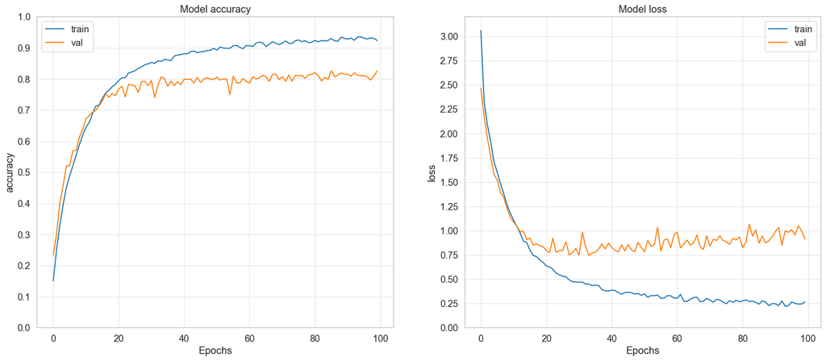

```python
plot_history(BaselineModel31, BaselineModel31_history, epochs)
```

**Observations**:

- Compared to the base model of the 128x128 model, the base model has a slightly worse performance with the validation accuracy at only around 80%
- As such, there is still a lot of improvements to be made with the model loss being very high at around 1.0
- Another important thing to note is that the model loss learning curve despite being high does not fluctuate as much compared to the one from the 128x128 model. This means that the learning rate does not have to be reduced as much

```python
perf_31_models = pd.DataFrame()

perf_31_models = save_model_performance(perf_31_models, BaselineModel31, BaselineModel31_history, "Original")
display(perf_31_models)
```

|  | Data | Mean loss | Mean accuracy | Mean val_loss | Mean val_accuracy |
| --- | --- | --- | --- | --- | --- |
| BaselineModel | Original | 0.539683 | 0.832223 | 0.960666 | 0.758427 |

##### Adding Additional Data using Data Augmentation

In order to try and further improve the performance of our baseline model, we can try to add in additional data into our dataset by using data augmentation. Data Augmentation is a method to reduce the variance of a model by imposing random transformations on the data for training

The first augmentation that will be done will be rescaling the pixels in the images from a range of [0, 255] to a range of [0, 1]

```python
rescale = keras.Sequential(
    name="data_rescaling",
    layers=[
        Rescaling(1.0/255), # Value Preprocessing
    ]
)
```

```python
# Split the dataset into X_train and y_train
data = [(img.numpy(), classes[labels]) for img, labels in train_31]

# Convert the list to numpy arrays
X_train = np.array([img for img, label in data])
y_train = np.array([label for img, label in data])
```

Reasons for not using Zoom and Center Crop

We will mostly be using similar data augmentation techniques used in the 128x128 model. However, we will not be using zooming and center cropping since the images are already very small

This is because techniques like zoom and center croping will choose a specific part of the image to focus on which can be useful in scenarios where the object of interest in the image varies in size.

However, for smaller images like 31x31 pixels, zooming can be problematic since we are essentially ncreasing the size of the image without adding any new information. This can lead to a loss of detail and potentially distort the image, which can negatively impact the performance of our model

On the other hand, for larger images like 128x128 pixels, zooming can be more beneficial since they typically contain more detail and can handle more distortions without losing significant information.

```python
from keras.preprocessing.image import ImageDataGenerator
datagen = ImageDataGenerator(
        rotation_range=10, # rotation
        width_shift_range=0.1, # horizontal shift
        height_shift_range=0.1, # vertical shift
        shear_range=0.1, # shear
        horizontal_flip=True, # horizontal flip
)

# Generate images in batches of 256
aug_iter = datagen.flow(x=X_train, y=y_train, batch_size=256)
print("Previous shape: ", X_train.shape, y_train.shape)

# Generate batch of images
for i in range(60):
        image, label=next(aug_iter)

        X_train = np.append(X_train, image, axis=0)
        y_train = np.append(y_train, label)

print("New shape: ", X_train.shape, y_train.shape)
```

```
Previous shape:  (9028, 31, 31, 1) (9028,)
New shape:  (24200, 31, 31, 1) (24200,)
```

```python
class_to_index = {class_name: index for index, class_name in enumerate(classes)}
y_train_int = np.array([class_to_index[label] for label in y_train])
```

```python
# SHuffle the data
X_train, y_train_int = shuffle(X_train, y_train_int, random_state=seed)
```

```python
# Join x_train and y_train together and add it back to the train_31 dataset
aug_train_31 = tf.data.Dataset.from_tensor_slices((X_train, y_train_int))
```

```python
aug_counter = {}
for img, label in aug_train_31:
    if classes[label] not in aug_counter:
        aug_counter[classes[label]] = 1
    else:
        aug_counter[classes[label]] += 1

labels, counts = np.array(list(aug_counter.keys())), np.array(list(aug_counter.values()))

labels = labels[counts.argsort()[::-1]]
counts = counts[counts.argsort()[::-1]]

counts_df = pd.DataFrame(counts, columns=['counts'], index=labels)

display(counts_df)
```

|  | counts |
| --- | --- |
| Tomato | 2575 |
| Brinjal | 2349 |
| Pumpkin | 2167 |
| Cucumber | 2152 |
| Bean | 2086 |
| Broccoli | 1991 |
| Bitter_Gourd | 1927 |
| Cauliflower | 1570 |
| Papaya | 1524 |
| Cabbage | 1355 |
| Bottle_Gourd | 1196 |
| Potato | 1017 |
| Capsicum | 940 |
| Carrot | 689 |
| Radish | 662 |

#### Improvements Made for DataAugModel:

- An additional rescale model at the front which rescales the input images from a range of [0, 255] to a range of [0, 1] before feeding the rescaled data into the model
- Instead of feeding in the original data (train_31), the dataset with augmentation is fed into the model (aug_train_31). This increases our training data from 9,000 to around 24,000
- Decrease the learning rate by 50% from the default of 0.001 to a slightly smaller learning rate of 0.0005 to try and help improve the models performance

```python
# Model with data augmentation but no balancing
DataAugModel31 = Sequential(
    name="DataAugModel",
    layers=[
    rescale,

    Conv2D(filters=64, kernel_size=3, strides=2, padding='same', activation='relu', input_shape=(31, 31, 1)),
    MaxPooling2D(pool_size=2),

    Conv2D(filters=128, kernel_size=3, strides=1, padding='same', activation='relu'),
    MaxPooling2D(pool_size=2),

    Flatten(),
    Dropout(0.6),
    Dense(128, activation='relu'),
    Dense(num_classes, activation='softmax')
])

DataAugModel31.compile(
    optimizer=Adam(learning_rate=0.000_5),
    loss='sparse_categorical_crossentropy',
    metrics=['accuracy']
)

DataAugModel31.build(input_shape=(None, 31, 31, 1))

DataAugModel31.summary()

epochs = 100
DataAugModel31_history = DataAugModel31.fit(
    aug_train_31.batch(batch_size),
    validation_data=val_31.batch(batch_size),
    epochs=epochs
)
```

```
Model: "DataAugModel"
_________________________________________________________________
 Layer (type)                Output Shape              Param #
=================================================================
 data_rescaling (Sequential)  (None, 31, 31, 1)        0

 conv2d_52 (Conv2D)          (None, 16, 16, 64)        640

 max_pooling2d_47 (MaxPoolin  (None, 8, 8, 64)         0
 g2D)

 conv2d_53 (Conv2D)          (None, 8, 8, 128)         73856

 max_pooling2d_48 (MaxPoolin  (None, 4, 4, 128)        0
 g2D)

 flatten_17 (Flatten)        (None, 2048)              0

 dropout_20 (Dropout)        (None, 2048)              0

 dense_37 (Dense)            (None, 128)               262272

 dense_38 (Dense)            (None, 15)                1935

=================================================================
Total params: 338,703
Trainable params: 338,703
Non-trainable params: 0
_________________________________________________________________
```

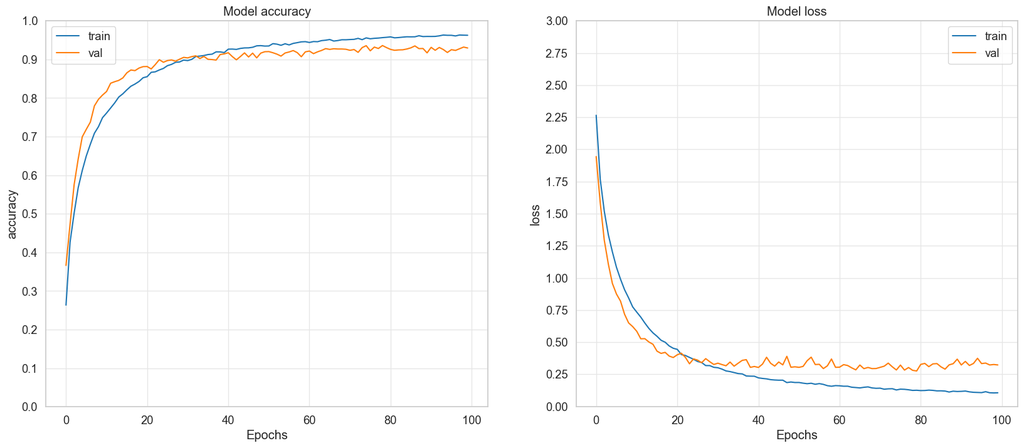

```python
plot_history(DataAugModel31, DataAugModel31_history, epochs)
```

```python
perf_31_models = save_model_performance(perf_31_models, DataAugModel31, DataAugModel31_history, "Augmented")
display(perf_31_models)
```

|  | Data | Mean loss | Mean accuracy | Mean val_loss | Mean val_accuracy |
| --- | --- | --- | --- | --- | --- |
| BaselineModel | Original | 0.539683 | 0.832223 | 0.960666 | 0.758427 |
| DataAugModel | Augmented | 0.335942 | 0.888484 | 0.414776 | 0.884810 |

##### Improving Architecture of CNN Model

In order to try and improve our models, here are some things we can change in our model's architecture:

- Increase number of convolutional layers: In order to try and capture more complex features, we can try to increase the number of convolutional layers being used in the model from 2 to 3 with an additional convolutional layer of 256
- Increase kernel size: In order to try and detect larger features, we can try and increase the kernel size of our model for the first few layer to (5, 5)
- Add BatchNormalization: In order to try and reduce overfitting, we can use batch normalization to make the model more stable by normalizing the inputs through re-centering and re-scaling

With these new chages, here is the new architecture of the model

CNN Improved Model Architecture

1. Convolutional Layer
- Filters: 64
- Kernel Size: (5, 5)
- Strides: (1, 1)
- Padding: 'same'
- Activation Function: 'relu'
2. MaxPooling
- Pool Size: (2, 2)
3. Convolutional Layer
- Filters: 128
- Kernel Size: (3, 3)
- Strides: (1, 1)
- Padding: 'same'
- Activation Function: 'relu'
4. MaxPooling
- Pool Size: (2, 2)
5. Convolutional Layer
- Filters: 256
- Kernel Size: (3, 3)
- Strides: (1, 1)
- Padding: 'same'
- Activation Function: 'relu'
6. MaxPooling
- Pool Size: (2, 2)
- Activation Function: 'relu'
7. Fully Connected Layer
- Neurons: 128
- Activation Function: 'relu'
8. Batch Normalization
9. Output Layer
- Neurons: 15 (number of classes)
- Activation Function: 'softmax'

Optimizer: Adam (learning rate = 0.000,5) Epochs: 100

```python
# Model with data augmentation but no balancing
ImprovedArchModel31 = Sequential(
    name="ImprovedArchitectureModel",
    layers=[
    rescale,

    Conv2D(filters=64, kernel_size=5, strides=1, padding='same', activation='relu', input_shape=(31, 31, 1)),
    MaxPooling2D(pool_size=2),

    Conv2D(filters=128, kernel_size=3, strides=1, padding='same', activation='relu'),
    MaxPooling2D(pool_size=2),

    Conv2D(filters=256, kernel_size=3, strides=1, padding='same', activation='relu'),
    MaxPooling2D(pool_size=2),

    Flatten(),
    Dropout(0.6),
    Dense(128, activation='relu'),
    BatchNormalization(),
    Dense(num_classes, activation='softmax')
])

ImprovedArchModel31.compile(
    optimizer=Adam(learning_rate=0.000_5),
    loss='sparse_categorical_crossentropy',
    metrics=['accuracy']
)

ImprovedArchModel31.build(input_shape=(None, 31, 31, 1))

ImprovedArchModel31.summary()

epochs = 100
ImprovedArchModel31_history = ImprovedArchModel31.fit(
    aug_train_31.batch(batch_size),
    validation_data=val_31.batch(batch_size),
    epochs=epochs
)
```

```
Model: "ImprovedArchitectureModel"
_________________________________________________________________
 Layer (type)                Output Shape              Param #
=================================================================
 data_rescaling (Sequential)  (None, 31, 31, 1)        0

 conv2d_54 (Conv2D)          (None, 31, 31, 64)        1664

 max_pooling2d_49 (MaxPoolin  (None, 15, 15, 64)       0
 g2D)

 conv2d_55 (Conv2D)          (None, 15, 15, 128)       73856

 max_pooling2d_50 (MaxPoolin  (None, 7, 7, 128)        0
 g2D)

 conv2d_56 (Conv2D)          (None, 7, 7, 256)         295168

 max_pooling2d_51 (MaxPoolin  (None, 3, 3, 256)        0
 g2D)

 flatten_18 (Flatten)        (None, 2304)              0

 dropout_21 (Dropout)        (None, 2304)              0

 dense_39 (Dense)            (None, 128)               295040

 batch_normalization_10 (Bat  (None, 128)              512
 chNormalization)

 dense_40 (Dense)            (None, 15)                1935

=================================================================
Total params: 668,175
Trainable params: 667,919
Non-trainable params: 256
_________________________________________________________________
```

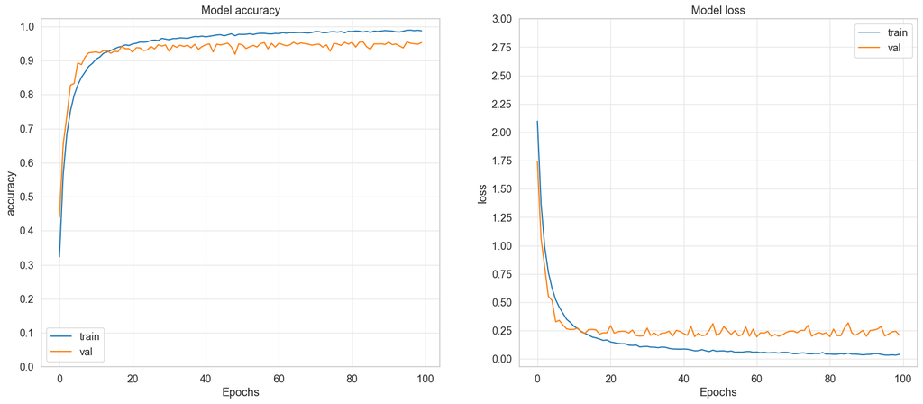

```python
plot_history(ImprovedArchModel31, ImprovedArchModel31_history, epochs)
```

**Observations**:

- With the addition of batch normalization, the learning curve for the validation set now no longer seems to fluctuate as much as before
- The improved architecture also seems to have improved the model's performance as it now converges to a validation accuracy of 90% much faster compared to before

```python
perf_31_models = save_model_performance(perf_31_models, ImprovedArchModel31, ImprovedArchModel31_history, "Augmented")
display(perf_31_models)
```

|  | Data | Mean loss | Mean accuracy | Mean val_loss | Mean val_accuracy |
| --- | --- | --- | --- | --- | --- |
| BaselineModel | Original | 0.539683 | 0.832223 | 0.960666 | 0.758427 |
| DataAugModel | Augmented | 0.335942 | 0.888484 | 0.414776 | 0.884810 |
| ImprovedArchitectureModel | Augmented | 0.155620 | 0.948706 | 0.273531 | 0.928207 |

##### Balancing Classes using Data Augmentation

As seen previously during the EDA, the number of images for each vegetable is not balanced with vegetables like tomato having as many as 900 images and other vegetables as radish only having 200 images

Instead of just adding data randomly using data augmentation to reduce the variance of our model, we can also use data augmentation to strategically add the number of images for each class such that it becomes more balanced. By doing so, our model will have enough training data for each class

```python
# Clear memory in space
# IMPORTANT STEP OTHERWISE DATASET CANNOT BE CREATED
del aug_train_31
```

```python
# Split the dataset into X_train and y_train
data = [(img.numpy(), classes[labels]) for img, labels in train_31]

# Convert the list to numpy arrays
X_train = np.array([img for img, label in data])
y_train = np.array([label for img, label in data])
```

```python
counter = {}
for label in y_train:
    if label not in counter:
        counter[label] = 1
    else:
        counter[label] += 1
```

In order to balance the classes, we will try to use increase the number of images for each class to a value of $N$ (where in this case, $N$ = 1750).

The eventual number of images generated however, will not be exactly the value $N$ but will be $$ImagesGenerated = {\lfloor \frac{N - CurrentNumberOfImages}{BatchSize} \rfloor} $$

When using ImageDataGenerator, generating the images one by one will be too slow so the images are usually generated in batches where a larger batch size will generate images quicker.

However, using a larger batch size means that we have less control over how many images get generated so the number of classes of each vegetable might be quite far from $N$.

As such, we will try to use a batch size of 32 so that we have some control over how many images get generated but the generation proces won't take too long

```python
# Split the training data into different classes
train_31_ds = {}

for vegetable in classes:
    mask = y_train == vegetable
    train_31_ds[vegetable] = X_train[mask]

aug_batch_size = 32

N = 1750

# Get the number of images to generate for each class and convert it to the nearest
num_batches = {vegetable: (N - counter[vegetable]) // aug_batch_size for vegetable in classes}

# Generate images for each class
for vegetable in classes:
    print(f"[{classes.index(vegetable)+1}/15] Generating Images for: {vegetable}")
    aug_iter = datagen.flow(x=train_31_ds[vegetable], y=[vegetable]*len(train_31_ds[vegetable]), batch_size=aug_batch_size)
    print("Initial Length: ", len(train_31_ds[vegetable]))
    print("Adding", num_batches[vegetable]*aug_batch_size, "Images")
    for i in range(num_batches[vegetable]):
        image, label=next(aug_iter)
        train_31_ds[vegetable] = np.append(train_31_ds[vegetable], image, axis=0)

    print("Current Length: ", len(train_31_ds[vegetable]))
    print('\n')

# Concatenate all the images together
X_train_bal = np.concatenate([train_31_ds[vegetable] for vegetable in classes], axis=0)
y_train_bal = np.concatenate([[vegetable]*len(train_31_ds[vegetable]) for vegetable in classes], axis=0)

print("New Shape: ", X_train_bal.shape, y_train_bal.shape)
```

```
[1/15] Generating Images for: Bean
Initial Length:  780
Adding 960 Images
Current Length:  1720


[2/15] Generating Images for: Bitter_Gourd
Initial Length:  720
Adding 1024 Images
Current Length:  1728


[3/15] Generating Images for: Bottle_Gourd
Initial Length:  441
Adding 1280 Images
Current Length:  1707


[4/15] Generating Images for: Brinjal
Initial Length:  868
Adding 864 Images
Current Length:  1732


[5/15] Generating Images for: Broccoli
Initial Length:  750
Adding 992 Images
Current Length:  1724


[6/15] Generating Images for: Cabbage
Initial Length:  503
Adding 1216 Images
Current Length:  1701


[7/15] Generating Images for: Capsicum
Initial Length:  351
Adding 1376 Images
Current Length:  1724
```

[output cut: 36 more lines]

```


[14/15] Generating Images for: Radish
Initial Length:  248
Adding 1472 Images
Current Length:  1680


[15/15] Generating Images for: Tomato
Initial Length:  955
Adding 768 Images
Current Length:  1723


New Shape:  (25759, 31, 31, 1) (25759,)
```

```python
# Convert the labels to integers
y_train_bal_int = np.array([class_to_index[label] for label in y_train_bal])
```

```python
# Randomly shuffle X_train_bal and y_train_bal in the same manner
X_train_bal, y_train_bal = shuffle(X_train_bal, y_train_bal_int, random_state=seed)
```

```python
bal_train_31 = tf.data.Dataset.from_tensor_slices((X_train_bal, y_train_bal))
bal_train_31 = try_unbatch(bal_train_31)
```

```python
counter = {}
for img, label in bal_train_31:
    if classes[label] not in counter:
        counter[classes[label]] = 1
    else:
        counter[classes[label]] += 1

labels, counts = np.array(list(counter.keys())), np.array(list(counter.values()))
```

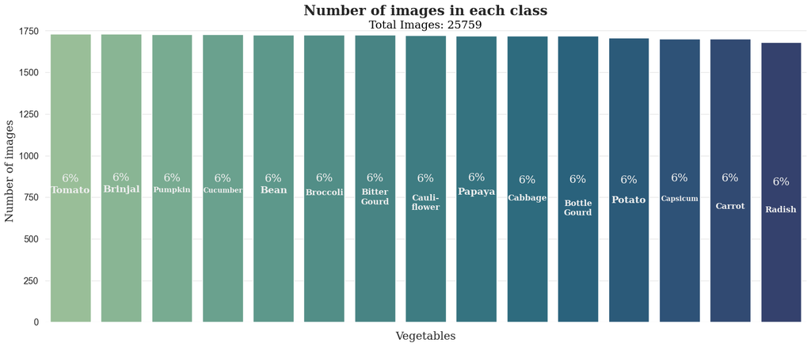

```python
# Plot a bar chart of the number of images in each class
fig, ax = plt.subplots(figsize=(20, 8))
sns.set_context('notebook',  font_scale=1.2)
sns.set_style('whitegrid', {'grid.color': '0.9'})

plt.box(False)

labels = labels[counts.argsort()[::-1]]
counts = counts[counts.argsort()[::-1]]

counts_df = pd.DataFrame(counts, columns=['counts'], index=labels)

sns.barplot(counts_df, x=counts_df.index, y='counts', palette='crest', hue=counts_df.index, ax=ax)

# Get actual counts of each class
tomato = counts_df.loc['Tomato']['counts']
brinjal = counts_df.loc['Brinjal']['counts']
pumpkin = counts_df.loc['Pumpkin']['counts']
cucumber = counts_df.loc['Cucumber']['counts']
bean = counts_df.loc['Bean']['counts']
broccoli = counts_df.loc['Broccoli']['counts']
bitterGourd = counts_df.loc['Bitter_Gourd']['counts']
cauliflower = counts_df.loc['Cauliflower']['counts']
papaya = counts_df.loc['Papaya']['counts']
cabbage = counts_df.loc['Cabbage']['counts']
bottleGourd = counts_df.loc['Bottle_Gourd']['counts']
potato = counts_df.loc['Potato']['counts']
capsicum = counts_df.loc['Capsicum']['counts']
carrot = counts_df.loc['Carrot']['counts']
raddish = counts_df.loc['Radish']['counts']
total = counts_df['counts'].sum()

# Annotations

# Tomato
plt.annotate(f"{int((tomato/total)*100)}%", xy=(0, tomato//2), fontfamily='serif', fontsize=16,
                ha='center', va='center', color='#eeeeee')
plt.annotate(f"Tomato", xy=(0, tomato//2 - tomato//24), fontfamily='serif', fontsize=14, fontweight='bold',
                va='center', ha='center', color="#eeeeee")

# Brinjal
plt.annotate(f"{int((brinjal/total)*100)}%", xy=(1, brinjal//2), fontfamily='serif', fontsize=16,
                ha='center', va='center', color='#eeeeee')
plt.annotate(f"Brinjal", xy=(1, brinjal//2 - brinjal//24), fontfamily='serif', fontsize=14, fontweight='bold',
                va='center', ha='center', color="#eeeeee")

# Pumpkin
plt.annotate(f"{int((pumpkin/total)*100)}%", xy=(2, pumpkin//2), fontfamily='serif', fontsize=16,
                ha='center', va='center', color='#eeeeee')
plt.annotate(f"Pumpkin", xy=(2, pumpkin//2 - pumpkin//24), fontfamily='serif', fontsize=11, fontweight='bold',
                va='center', ha='center', color="#eeeeee")

# Cucumber
plt.annotate(f"{int((cucumber/total)*100)}%", xy=(3, cucumber//2), fontfamily='serif', fontsize=16,
                ha='center', va='center', color='#eeeeee')
plt.annotate(f"Cucumber", xy=(3, cucumber//2 - cucumber//24), fontfamily='serif', fontsize=10, fontweight='bold',
                va='center', ha='center', color="#eeeeee")

# Bean
plt.annotate(f"{int((bean/total)*100)}%", xy=(4, bean//2), fontfamily='serif', fontsize=16,
                ha='center', va='center', color='#eeeeee')
plt.annotate(f"Bean", xy=(4, bean//2 - bean//24), fontfamily='serif', fontsize=14, fontweight='bold',
                va='center', ha='center', color="#eeeeee")

# Broccoli
plt.annotate(f"{int((broccoli/total)*100)}%", xy=(5, broccoli//2), fontfamily='serif', fontsize=16,
                ha='center', va='center', color='#eeeeee')
plt.annotate(f"Broccoli", xy=(5, broccoli//2 - broccoli//20), fontfamily='serif', fontsize=12, fontweight='bold',
                va='center', ha='center', color="#eeeeee")

# Bitter Gourd
plt.annotate(f"{int((bitterGourd/total)*100)}%", xy=(6, bitterGourd//2), fontfamily='serif', fontsize=16,
                ha='center', va='center', color='#eeeeee')
plt.annotate(f"Bitter\nGourd", xy=(6, bitterGourd//2 - bitterGourd//15), fontfamily='serif', fontsize=12, fontweight='bold',
                va='center', ha='center', color="#eeeeee")

# Cauliflower
plt.annotate(f"{int((cauliflower/total)*100)}%", xy=(7, cauliflower//2), fontfamily='serif', fontsize=16,
                ha='center', va='center', color='#eeeeee')
plt.annotate(f"Cauli-\nflower", xy=(7, cauliflower//2 - cauliflower//12), fontfamily='serif', fontsize=12, fontweight='bold',
                va='center', ha='center', color="#eeeeee")

# Papaya
plt.annotate(f"{int((papaya/total)*100)}%", xy=(8, papaya//2), fontfamily='serif', fontsize=16,
                ha='center', va='center', color='#eeeeee')
plt.annotate(f"Papaya", xy=(8, papaya//2 - papaya//20), fontfamily='serif', fontsize=14, fontweight='bold',
                va='center', ha='center', color="#eeeeee")

# Cabbage
plt.annotate(f"{int((cabbage/total)*100)}%", xy=(9, cabbage//2), fontfamily='serif', fontsize=16,
                ha='center', va='center', color='#eeeeee')
plt.annotate(f"Cabbage", xy=(9, cabbage//2 - cabbage//16), fontfamily='serif', fontsize=12, fontweight='bold',
                va='center', ha='center', color="#eeeeee")

# Bottle Gourd
plt.annotate(f"{int((bottleGourd/total)*100)}%", xy=(10, bottleGourd//2), fontfamily='serif', fontsize=16,
                ha='center', va='center', color='#eeeeee')
plt.annotate(f"Bottle\nGourd", xy=(10, bottleGourd//2 - bottleGourd//10), fontfamily='serif', fontsize=12, fontweight='bold',
                va='center', ha='center', color="#eeeeee")

# Potato
plt.annotate(f"{int((potato/total)*100)}%", xy=(11, potato//2), fontfamily='serif', fontsize=16,
                ha='center', va='center', color='#eeeeee')
plt.annotate(f"Potato", xy=(11, potato//2 - potato//14), fontfamily='serif', fontsize=14, fontweight='bold',
                va='center', ha='center', color="#eeeeee")

# Capsicum
plt.annotate(f"{int((capsicum/total)*100)}%", xy=(12, capsicum//2), fontfamily='serif', fontsize=16,
                ha='center', va='center', color='#eeeeee')
plt.annotate(f"Capsicum", xy=(12, capsicum//2 - capsicum//14), fontfamily='serif', fontsize=10, fontweight='bold',
                va='center', ha='center', color="#eeeeee")

# Carrot
plt.annotate(f"{int((carrot/total)*100)}%", xy=(13, carrot//2), fontfamily='serif', fontsize=16,
                ha='center', va='center', color='#eeeeee')
plt.annotate(f"Carrot", xy=(13, carrot//2 - carrot//10), fontfamily='serif', fontsize=12, fontweight='bold',
                va='center', ha='center', color="#eeeeee")

# Radish
plt.annotate(f"{int((raddish/total)*100)}%", xy=(14, raddish//2), fontfamily='serif', fontsize=16,
                ha='center', va='center', color='#eeeeee')
plt.annotate(f"Radish", xy=(14, raddish//2 - raddish//10), fontfamily='serif', fontsize=12, fontweight='bold',
                va='center', ha='center', color="#eeeeee")


plt.annotate(f"Total Images: {total}", xy=(7, 1780), fontfamily='serif', fontsize=16,
                ha='center', va='center', color='#000000')

plt.title('Number of images in each class', fontfamily='serif', fontsize=20, fontweight='bold')
ax.set_xticklabels([])
ax.set_xlabel('Vegetables', fontfamily='serif', fontsize=16)
ax.set_ylabel('Number of images', fontfamily='serif', fontsize=16)

plt.show()
```

**Observations**:

- Although the number of images are not exactly the same, they are close enough such that they all make up 6% of the data
- From the graph, we can now see that our training set is balanced

- Instead of feeding in the dataset with augmentation (aug_train_31), the **balanced** dataset with augmentation is fed into the model (bal_train_31). This increases our training slightly data from 24,200 to around 25,700 but more importantly, it balances the number of images to around 1750 for each class

```python
BalModel31 = Sequential(
    name="BalancedModel",
    layers=[
    # Preprocessing Layer
    rescale,

    Conv2D(filters=64, kernel_size=5, strides=1, padding='same', activation='relu', input_shape=(31, 31, 1)),
    MaxPooling2D(pool_size=2),

    Conv2D(filters=128, kernel_size=3, strides=1, padding='same', activation='relu'),
    MaxPooling2D(pool_size=2),

    Conv2D(filters=256, kernel_size=3, strides=1, padding='same', activation='relu'),
    MaxPooling2D(pool_size=2),

    Flatten(),
    Dropout(0.6),
    Dense(128, activation='relu'),
    BatchNormalization(),
    Dense(num_classes, activation='softmax')
])

BalModel31.compile(
    optimizer=Adam(learning_rate=0.000_5),
    loss='sparse_categorical_crossentropy',
    metrics=['accuracy']
)

BalModel31.build(input_shape=(None, 31, 31, 1))

BalModel31.summary()

epochs = 100
BalModel31_history = BalModel31.fit(
    bal_train_31.batch(batch_size),
    validation_data=val_31.batch(batch_size),
    epochs=epochs,
)
```

[output not shown]

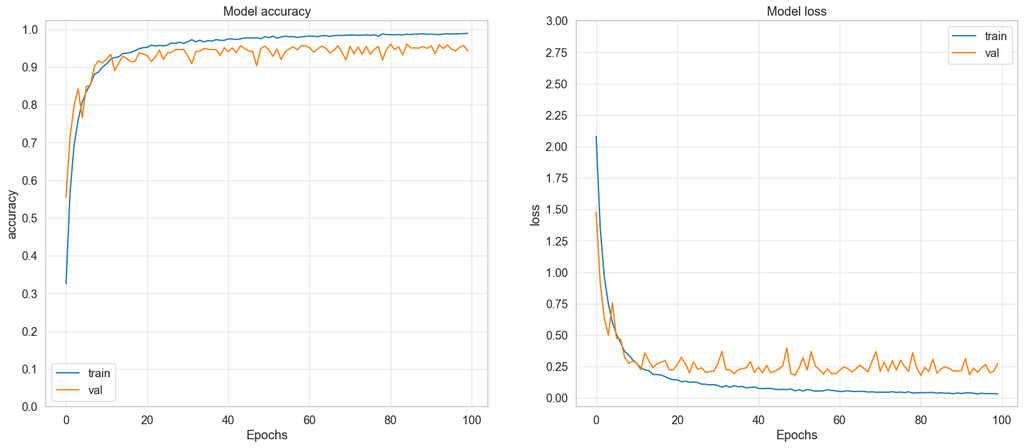

```python
plot_history(BalModel31, BalModel31_history, epochs)
```

**Observations**:

- After balancing the dataset, there is not much change in both accuracy and loss compared to in the 128x128 model

```python
perf_31_models = save_model_performance(perf_31_models, BalModel31, BalModel31_history, "Balanced Augmented")
display(perf_31_models)
```

|  | Data | Mean loss | Mean accuracy | Mean val_loss | Mean val_accuracy |
| --- | --- | --- | --- | --- | --- |
| BaselineModel | Original | 0.539683 | 0.832223 | 0.960666 | 0.758427 |
| DataAugModel | Augmented | 0.335942 | 0.888484 | 0.414776 | 0.884810 |
| ImprovedArchitectureModel | Augmented | 0.155620 | 0.948706 | 0.273531 | 0.928207 |
| BalancedModel | Balanced Augmented | 0.148900 | 0.950973 | 0.283400 | 0.927940 |

##### Using a Learning Rate Scheduler

For the training of our model, we will still be using time based decay. However we will reduce the value of $k$ to 25 instead of 100

```python
def timeDecay31(epoch, lr):
    initial_lr = 0.000_25
    # Use k to speed up the decay
    k = 25
    # + 1 to avoid division by 0
    decay = initial_lr/(epoch+1)
    return lr * 1/ (1 + k * decay * epoch)

learningRateScheduler31 = keras.callbacks.LearningRateScheduler(timeDecay31)
```

```python
FinalModel31 = Sequential(
    name="FinalModel",
    layers=[
    # Preprocessing Layer
    rescale,

    Conv2D(filters=64, kernel_size=5, strides=1, padding='same', activation='relu', input_shape=(31, 31, 1)),
    MaxPooling2D(pool_size=2),

    Conv2D(filters=128, kernel_size=3, strides=1, padding='same', activation='relu'),
    MaxPooling2D(pool_size=2),

    Conv2D(filters=256, kernel_size=3, strides=1, padding='same', activation='relu'),
    MaxPooling2D(pool_size=2),

    Flatten(),
    Dropout(0.6),
    Dense(128, activation='relu'),
    BatchNormalization(),
    Dense(num_classes, activation='softmax')
])

FinalModel31.compile(
    optimizer=Adam(learning_rate=0.000_5),
    loss='sparse_categorical_crossentropy',
    metrics=['accuracy']
)

FinalModel31.build(input_shape=(None, 31, 31, 1))

FinalModel31.summary()

epochs = 100
FinalModel31_history = FinalModel31.fit(
    bal_train_31.batch(batch_size),
    validation_data=val_31.batch(batch_size),
    epochs=epochs,
    callbacks=[learningRateScheduler31]
)
```

[output not shown]

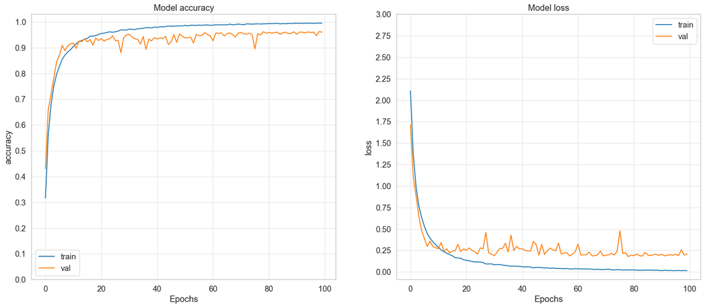

```python
plot_history(FinalModel31, FinalModel31_history, epochs)
```

```python
# Remove last row
perf_31_models = perf_31_models[:-1]
```

```python
perf_31_models = save_model_performance(perf_31_models, FinalModel31, FinalModel31_history, "Balanced Augmented")
display(perf_31_models)
```

|  | Data | Mean loss | Mean accuracy | Mean val_loss | Mean val_accuracy |
| --- | --- | --- | --- | --- | --- |
| BaselineModel | Original | 0.539683 | 0.832223 | 0.960666 | 0.758427 |
| DataAugModel | Augmented | 0.335942 | 0.888484 | 0.414776 | 0.884810 |
| ImprovedArchitectureModel | Augmented | 0.155620 | 0.948706 | 0.273531 | 0.928207 |
| BalancedModel | Balanced Augmented | 0.148900 | 0.950973 | 0.283400 | 0.927940 |
| FinalModel | Balanced Augmented | 0.136447 | 0.955361 | 0.281167 | 0.927093 |

### **Model Evaluation**

Let us look at how both of our final model performs on the test dataset and compare their performances

```python
print("EVALUATION FOR 31x31 MODEL")
test_loss, test_acc = FinalModel31.evaluate(test_31.batch(32))
print("Test Loss: ", test_loss)
print("Test Accuracy: ", test_acc)

print(f"\n{'-'*100}")

print("EVALUATION FOR 128x128 MODEL")
test_loss, test_acc = FinalModel.evaluate(test_128.batch(64))
print("Test Loss: ", test_loss)
print("Test Accuracy: ", test_acc)
```

[output not shown]

**Observations**:

- Overall, the 128x128 model had a slightly better performance at an accuracy of 97.1% compared to the 31x31 model of 95.7%
- Their test loss is also quite similar at around 14.6% and 18.9%
- However, there are multiple metrics used to evaluate classification tasks and we cannot solely rely on accuracy for a fair comparison between the two models

Let us also evaluate both models using scikit learn's classification report which will produce a report with the precision, recall and F1-score for each class

```python
# Get X_test and y_test
data = [(img.numpy(), classes[labels]) for img, labels in test_31]

# Convert the list to numpy arrays
X_test = np.array([img for img, label in data])
y_test = np.array([label for img, label in data])

# Convert y_test to integer labels
y_test_int = np.array([class_to_index[label] for label in y_test])

y_pred = BalModel31.predict(X_test)

report31 = classification_report(
    y_test_int,
    np.argmax(y_pred, axis=1),
    target_names=classes
)
```

```python
# Get X_test and y_test
data = [(img.numpy(), classes[labels]) for img, labels in test_128]

# Convert the list to numpy arrays
X_test = np.array([img for img, label in data])
y_test = np.array([label for img, label in data])

# Convert y_test to integer labels
y_test_int = np.array([class_to_index[label] for label in y_test])

y_pred = FinalModel.predict(X_test)

report = classification_report(
    y_test_int,
    np.argmax(y_pred, axis=1),
    target_names=classes
)
```

```python
print("EVALUATION FOR 31x31 MODEL")
print(report31)

print(f"\n{'-'*100}")

print("EVALUATION FOR 128x128 MODEL")
print(report)
```

```
EVALUATION FOR 31x31 MODEL
              precision    recall  f1-score   support

        Bean       0.97      0.96      0.97       200
Bitter_Gourd       0.91      0.96      0.93       200
Bottle_Gourd       0.99      0.99      0.99       200
     Brinjal       0.92      0.95      0.94       200
    Broccoli       0.86      0.98      0.92       200
     Cabbage       0.85      0.90      0.87       200
    Capsicum       0.98      0.95      0.97       200
      Carrot       1.00      0.88      0.93       200
 Cauliflower       0.94      0.94      0.94       200
    Cucumber       0.99      0.93      0.96       200
      Papaya       0.99      0.94      0.97       200
      Potato       0.94      0.90      0.92       200
     Pumpkin       0.86      0.95      0.90       200
      Radish       1.00      0.90      0.94       200
      Tomato       0.89      0.93      0.91       200

    accuracy                           0.94      3000
   macro avg       0.94      0.94      0.94      3000
weighted avg       0.94      0.94      0.94      3000


----------------------------------------------------------------------------------------------------
EVALUATION FOR 128x128 MODEL
              precision    recall  f1-score   support

        Bean       0.98      0.98      0.98       200
Bitter_Gourd       0.97      0.98      0.97       200
Bottle_Gourd       0.98      1.00      0.99       200
     Brinjal       0.93      0.95      0.94       200
    Broccoli       0.98      0.98      0.98       200
     Cabbage       0.95      0.96      0.96       200
    Capsicum       0.99      0.98      0.99       200
      Carrot       0.99      0.96      0.98       200
 Cauliflower       0.96      0.96      0.96       200
    Cucumber       0.95      0.99      0.97       200
      Papaya       1.00      0.98      0.99       200
      Potato       0.97      0.96      0.96       200
     Pumpkin       0.97      0.97      0.97       200
      Radish       0.97      0.97      0.97       200
      Tomato       0.97      0.92      0.94       200

    accuracy                           0.97      3000
   macro avg       0.97      0.97      0.97      3000
weighted avg       0.97      0.97      0.97      3000
```

**Observations**:

Since we used about the similar improvement steps to derive our final model, let us take a look at how much each step has improved the overall performance of the model

```python
print("31X31 Models")
display(perf_31_models)
print("128X128 Models")
display(perf_128_models)
```

```
31X31 Models
```

|  | Data | Mean loss | Mean accuracy | Mean val_loss | Mean val_accuracy |
| --- | --- | --- | --- | --- | --- |
| BaselineModel | Original | 0.539683 | 0.832223 | 0.960666 | 0.758427 |
| DataAugModel | Augmented | 0.335942 | 0.888484 | 0.414776 | 0.884810 |
| ImprovedArchitectureModel | Augmented | 0.155620 | 0.948706 | 0.273531 | 0.928207 |
| BalancedModel | Balanced Augmented | 0.148900 | 0.950973 | 0.283400 | 0.927940 |
| FinalModel | Balanced Augmented | 0.136447 | 0.955361 | 0.281167 | 0.927093 |

```
128X128 Models
```

|  | Data | Mean loss | Mean accuracy | Mean val_loss | Mean val_accuracy |
| --- | --- | --- | --- | --- | --- |
| BaselineModel | Original | 0.177107 | 0.948607 | 0.749330 | 0.865227 |
| DataAugModel | Augmented | 0.164322 | 0.946507 | 0.509775 | 0.877827 |
| ImprovedArchitectureModel | Augmented | 0.142283 | 0.954847 | 0.348815 | 0.916610 |
| BalancedModel | Balanced Augmented | 0.134344 | 0.956594 | 0.245093 | 0.940640 |
| FinalModel | Balanced Augmented | 0.140035 | 0.955882 | 0.242838 | 0.942030 |

**Observations**:

- Comparing the baseline models, the 128x182 model has a much better performance but eventually, both were able to improve to a mean validation accuracy of above 90 percent
- For the 31x31 model, data augmentation managed to help improve the performance a lot dropping the mean validation loss from 0.96 to 0.41 and improving the model architecture helped improve it even further by reducing the validation loss to around 0.27. Howver after that, Balancing the Data and adding a learning rate scheduler did not help much in terms of the model's overall performance even though they did help slightly with the final validation accuracy
- This is also quite similar in the 128x128 model where data augmentation helped to significantly reduce the loss and improving the model architecture help further reduce it. However, in the 128x128 model, balancing the dataset alo seemed to have help improve the model which was not the case for the 31x31 model

**Final Thoughts on both models**:

- Overall, its seems that the 128x128 model has a better performance compared to the 31x31 model in terms of both accuracy and loss. However, the improvement in the performance is not a lot and the 31x31 model already has a very good performance on its on
- Another thing to note is that the 128x128 model took significantly longer to train compared to the 31x31 model in terms of both running the model and for the data augmentation where augmenting the 128x128 model took as long as one minute while augmenting te 31x31 model was much shorter at only a few seconds
- This means that if the perfect model is not needed and time is a huge concern, it would be better to go with a smaller image size like the 31x31 model since training it would be much shorter. However, if the goal is to have the best model possible, it would make more sense to use an even larger image size like the 128x128 model though in some cases like this one, the improvement won't be very drastic

### **Save Models**

Save all the models as a h5 file

```python
dir = os.path.join(os.getcwd(), "CNN_Models")

if not os.path.exists(dir):
    os.mkdir(dir)
else:
    for file in os.listdir(dir):
        os.remove(os.path.join(dir, file))

dir_31 = os.path.join(dir, "31")
dir_128 = os.path.join(dir, "128")

if not os.path.exists(dir_31):
    os.mkdir(dir_31)
else:
    for file in os.listdir(dir_31):
        os.remove(os.path.join(dir_31, file))

BaselineModel31.save(os.path.join(dir_31, "BaselineModel_31.h5"))
DataAugModel31.save(os.path.join(dir_31, "DataAugModel_31.h5"))
ImprovedArchModel31.save(os.path.join(dir_31, "ImprovedArchModel_31.h5"))
BalModel31.save(os.path.join(dir_31, "BalModel_31.h5"))
FinalModel31.save(os.path.join(dir_31, "FinalModel_31.h5"))

if not os.path.exists(dir_128):
    os.mkdir(dir_128)
else:
    for file in os.listdir(dir_128):
        os.remove(os.path.join(dir_128, file))

BaselineModel.save(os.path.join(dir_128, "BaselineModel_128.h5"))
DataAugModel.save(os.path.join(dir_128, "DataAugModel_128.h5"))
ImprovedArchModel.save(os.path.join(dir_128, "ImprovedArchModel_128.h5"))
BalModel.save(os.path.join(dir_128, "BalModel_128.h5"))
FinalModel.save(os.path.join(dir_128, "FinalModel_128.h5"))
```